# Biostat 203B Homework 5

Due Mar 22 @ 11:59PM

Author

Kathy Hoang and 506333118

## Predicting ICU duration

Using the ICU cohort `mimiciv_icu_cohort.rds` you built in Homework 4, develop at least three machine learning approaches (logistic regression with enet regularization, random forest, boosting, SVM, MLP, etc) plus a model stacking approach for predicting whether a patient’s ICU stay will be longer than 2 days. You should use the `los_long` variable as the outcome. You algorithms can use patient demographic information (gender, age at ICU `intime`, marital status, race), ICU admission information (first care unit), the last lab measurements before the ICU stay, and first vital measurements during ICU stay as features. You are welcome to use any feature engineering techniques you think are appropriate; but make sure to not use features that are not available at an ICU stay’s `intime`. For instance, `last_careunit` cannot be used in your algorithms.

```r
# clean environment
rm(list = ls())
```

```r
# load libraries
library(bigrquery)
library(dbplyr)
library(DBI)
library(gt)
library(gtsummary)
library(tidyverse)
library(tidymodels)
library(GGally)
library(e1071) # skewedness
library(keras)
library(dials)
library(stacks)
library(vip)
library(NeuralNetTools)


## shared by Vem in OH to speed up the tuning process
library(doMC)
library(doParallel)
library(foreach)
```

```r
# updated .rds from hw4 folder  (Dr. Zhou said this was okay in OH)
mimiciv_icu_cohort <- readRDS("../hw4/mimiciv_shiny/mimic_icu_cohort.rds")
head(mimiciv_icu_cohort)
```

```
# A tibble: 6 × 43
  subject_id  hadm_id first_careunit           last_careunit intime
       <int>    <int> <fct>                    <fct>         <dttm>
1   10000032 29079034 Medical Intensive Care … Medical Inte… 2180-07-23 14:00:00
2   10000980 26913865 Medical Intensive Care … Medical Inte… 2189-06-27 08:42:00
3   10001217 24597018 Surgical Intensive Care… Surgical Int… 2157-11-20 19:18:02
4   10001217 27703517 Surgical Intensive Care… Surgical Int… 2157-12-19 15:42:24
5   10001725 25563031 Medical/Surgical Intens… Medical/Surg… 2110-04-11 15:52:22
6   10001884 26184834 Medical Intensive Care … Medical Inte… 2131-01-11 04:20:05
# ℹ 38 more variables: outtime <dttm>, los <dbl>, admittime <dttm>,
#   dischtime <dttm>, deathtime <dttm>, admission_type <fct>,
#   admit_provider_id <chr>, admission_location <fct>,
#   discharge_location <fct>, insurance <chr>, language <chr>,
#   marital_status <chr>, race <fct>, edregtime <dttm>, edouttime <dttm>,
#   hospital_expire_flag <int>, gender <chr>, anchor_age <int>,
#   anchor_year <int>, anchor_year_group <chr>, dod <date>, …
```

### 1. Data Preprocessing and Feature Engineering.

In this section, I will clean, transform, and standardize the data to prepare the data for the machine learning models, in order to ensure data quality and improve model performance. For example, I will handle missing values by imputing, categorical variables with one-hot encoding, and skewed numerical variables with log transformation. Note that some of the data preprocessing steps are done when creating the recipe for the models.

When selecting features, I chose to keep the patient’s demographic information, lab measurements, and vital signs. I believe these features can be important predictors of a patient’s length of stay in the ICU. From the exploratory data analysis in hw3, I noticed that the length of stay did not vary much by insurance status and gender. Thus, I believe insurance status is an unnecessary predictor and removed it from the dataset. I intend to use gender to create new ratio features, as some health measurements may differ by gender (ex. normal range for Hematocrit).

```r
# Select Relevant Columns
mimiciv_icu_cohort_preprocessed <- mimiciv_icu_cohort |>
  # demographic info
  select(
    subject_id, hadm_id, stay_id, gender,
    age_at_intime, marital_status, race, los_long,
    # ICU admission information
    # last lab measurements before the ICU stay (alrdy filtered)
    first_careunit, Bicarbonate, Potassium, Chloride, Glucose,
    Creatinine, Glucose, Hematocrit, Sodium, White_Blood_Cells,
    # first vital measurements during ICU stay (alrdy filtered)
    Non_Invasive_BP_diastolic, Non_Invasive_BP_systolic,
    Temperature_Fahrenheit, Respiratory_Rate, Heart_Rate
  )
mimiciv_icu_cohort_preprocessed |> print(width = Inf)
```

```
# A tibble: 73,181 × 22
   subject_id  hadm_id  stay_id gender age_at_intime marital_status race
        <int>    <int>    <int> <chr>          <int> <chr>          <fct>
 1   10000032 29079034 39553978 F                 52 WIDOWED        WHITE
 2   10000980 26913865 39765666 F                 76 MARRIED        BLACK
 3   10001217 24597018 34592300 F                 55 MARRIED        WHITE
 4   10001217 27703517 34592300 F                 55 MARRIED        WHITE
 5   10001725 25563031 31205490 F                 46 MARRIED        WHITE
 6   10001884 26184834 37510196 F                 77 MARRIED        BLACK
 7   10002013 23581541 39060235 F                 57 SINGLE         Other
 8   10002155 20345487 31090461 F                 83 MARRIED        WHITE
 9   10002155 23822395 31090461 F                 81 MARRIED        WHITE
10   10002155 28994087 31090461 F                 82 MARRIED        WHITE
   los_long first_careunit                                   Bicarbonate
   <lgl>    <fct>                                                  <dbl>
```

[output cut: 47 more lines]

```r
str(mimiciv_icu_cohort_preprocessed)
```

```
tibble [73,181 × 22] (S3: tbl_df/tbl/data.frame)
 $ subject_id               : int [1:73181] 10000032 10000980 10001217 10001217 10001725 10001884 10002013 10002155 10002155 10002155 ...
 $ hadm_id                  : int [1:73181] 29079034 26913865 24597018 27703517 25563031 26184834 23581541 20345487 23822395 28994087 ...
 $ stay_id                  : int [1:73181] 39553978 39765666 34592300 34592300 31205490 37510196 39060235 31090461 31090461 31090461 ...
 $ gender                   : chr [1:73181] "F" "F" "F" "F" ...
 $ age_at_intime            : int [1:73181] 52 76 55 55 46 77 57 83 81 82 ...
 $ marital_status           : chr [1:73181] "WIDOWED" "MARRIED" "MARRIED" "MARRIED" ...
 $ race                     : Factor w/ 5 levels "ASIAN","BLACK",..: 4 2 4 4 4 2 5 4 4 4 ...
 $ los_long                 : logi [1:73181] FALSE FALSE FALSE FALSE FALSE TRUE ...
 $ first_careunit           : Factor w/ 5 levels "Cardiac Vascular Intensive Care Unit (CVICU)",..: 2 2 4 4 3 2 1 2 5 3 ...
 $ Bicarbonate              : num [1:73181] 25 21 22 22 NA 30 24 23 23 23 ...
 $ Potassium                : num [1:73181] NA 3.9 4.1 4.1 4.1 4.5 3.5 4.6 4.6 4.6 ...
 $ Chloride                 : num [1:73181] 95 109 104 104 98 88 102 105 105 105 ...
 $ Glucose                  : num [1:73181] NA NA NA NA NA NA NA 138 138 138 ...
 $ Creatinine               : num [1:73181] 0.7 2.3 0.5 0.5 NA 1.1 0.9 1.1 1.1 1.1 ...
 $ Hematocrit               : num [1:73181] 41.1 27.3 37.4 37.4 NA 39.7 34.9 25.5 25.5 25.5 ...
 $ Sodium                   : num [1:73181] 126 144 142 142 139 130 137 135 135 135 ...
 $ White_Blood_Cells        : num [1:73181] 6.9 5.3 15.7 15.7 NA 12.2 7.2 17.9 17.9 17.9 ...
 $ Non_Invasive_BP_diastolic: num [1:73181] 48 77 90 90 56 12 70 51 51 51 ...
 $ Non_Invasive_BP_systolic : num [1:73181] 84 150 151 151 73 180 104 109 109 109 ...
 $ Temperature_Fahrenheit   : num [1:73181] 98.7 98 97.6 97.6 97.7 98.1 97.2 95.9 95.9 95.9 ...
 $ Respiratory_Rate         : num [1:73181] 24 23 11 11 19 10 14 18 18 18 ...
 $ Heart_Rate               : num [1:73181] 91 77 86 86 55 38 80 68 68 68 ...
```

After loading in the dataset, I observed the structure of the data and can see that there is some cleaning up to do. First, I will check for missing values so that I can take note of which variables I will need to impute later.

#### Missing Values

```r
missing_values <- colSums(is.na(mimiciv_icu_cohort_preprocessed))
missing_values
```

```
               subject_id                   hadm_id                   stay_id
                        0                         0                         0
                   gender             age_at_intime            marital_status
                        0                         0                      4810
                     race                  los_long            first_careunit
                        0                         0                         0
              Bicarbonate                 Potassium                  Chloride
                     8747                     15245                      7666
                  Glucose                Creatinine                Hematocrit
                    63028                      5284                      5296
                   Sodium         White_Blood_Cells Non_Invasive_BP_diastolic
                    16122                      5151                       503
 Non_Invasive_BP_systolic    Temperature_Fahrenheit          Respiratory_Rate
                      502                       783                        45
               Heart_Rate
                        1
```

```r
# need to impute missing values
# only marital_status is categorical and has missing values, rest are numeric
```

After checking for missing values, I observed that the only categorical variable with missing values is `marital_status`. I will impute this with the mode of the variable. The rest of the variables with missing values are numeric, and I will impute these with the mean of the variable. Note: this is done when creating the recipe for the models.

#### Outliers

Because outliers do not conform with the pattern of the data, they can affect the performance of the model and cause disruptions in the predictions. Thus, I chose to remove some outliers from the dataset.

I examined the plots generated in the Exploratory Data Analysis (EDA) section in HW3 to identify which variables had outliers and needed to be removed.

```r
# Outliers

# Creatinine
creat_col <- mimiciv_icu_cohort_preprocessed$Creatinine

# IQR method but with 5th and 95th percentiles
q1 <- quantile(creat_col, 0.05, na.rm = TRUE)
q3 <- quantile(creat_col, 0.95, na.rm = TRUE)
iqr <- q3 - q1
lower_bound <- q1 - 1.5 * iqr
upper_bound <- q3 + 1.5 * iqr

# Filter
mimiciv_icu_cohort_preprocessed <- mimiciv_icu_cohort_preprocessed |>
  filter(Creatinine >= lower_bound & Creatinine <= upper_bound)

num_out_removed <- length(creat_col) -
  length(mimiciv_icu_cohort_preprocessed$Creatinine)
print(paste("Number of Outliers Removed: ", num_out_removed))
```

```
[1] "Number of Outliers Removed:  6359"
```

```r
# Outliers

# White_Blood_Cells
wbc_col <- mimiciv_icu_cohort_preprocessed$White_Blood_Cells

# IQR method but with 5th and 95th percentiles
q1 <- quantile(wbc_col, 0.05, na.rm = TRUE)
q3 <- quantile(wbc_col, 0.95, na.rm = TRUE)
iqr <- q3 - q1
lower_bound <- q1 - 1.5 * iqr
upper_bound <- q3 + 1.5 * iqr

# Filter
mimiciv_icu_cohort_preprocessed <- mimiciv_icu_cohort_preprocessed |>
  filter(White_Blood_Cells >= lower_bound & White_Blood_Cells <= upper_bound)

num_out_removed <- length(wbc_col) -
  length(mimiciv_icu_cohort_preprocessed$White_Blood_Cells)
print(paste("Number of Outliers Removed: ", num_out_removed))
```

```
[1] "Number of Outliers Removed:  1525"
```

```r
# Outliers

# Heart Rate
hr_col <- mimiciv_icu_cohort_preprocessed$Heart_Rate

# IQR method but with 5th and 95th percentiles
q1 <- quantile(hr_col, 0.05, na.rm = TRUE)
q3 <- quantile(hr_col, 0.95, na.rm = TRUE)
iqr <- q3 - q1
lower_bound <- q1 - 1.5 * iqr
upper_bound <- q3 + 1.5 * iqr

# Filter
mimiciv_icu_cohort_preprocessed <- mimiciv_icu_cohort_preprocessed |>
  filter(Heart_Rate >= lower_bound & Heart_Rate <= upper_bound)

num_out_removed <- length(hr_col) -
  length(mimiciv_icu_cohort_preprocessed$Heart_Rate)
print(paste("Number of Outliers Removed: ", num_out_removed))
```

```
[1] "Number of Outliers Removed:  4"
```

```r
# Outliers

# Non_Invasive_BP_diastolic
nibpd_col <- mimiciv_icu_cohort_preprocessed$Non_Invasive_BP_diastolic

# IQR method but with 5th and 95th percentiles
q1 <- quantile(nibpd_col, 0.05, na.rm = TRUE)
q3 <- quantile(nibpd_col, 0.95, na.rm = TRUE)
iqr <- q3 - q1
lower_bound <- q1 - 1.5 * iqr
upper_bound <- q3 + 1.5 * iqr

# Filter
mimiciv_icu_cohort_preprocessed <- mimiciv_icu_cohort_preprocessed |>
  filter(Non_Invasive_BP_diastolic >= lower_bound &
    Non_Invasive_BP_diastolic <= upper_bound)

num_out_removed <- length(nibpd_col) -
  length(mimiciv_icu_cohort_preprocessed$Non_Invasive_BP_diastolic)
print(paste("Number of Outliers Removed: ", num_out_removed))
```

```
[1] "Number of Outliers Removed:  405"
```

```r
# Outliers

# Temperature Fahrenheit
nibpd_col <- mimiciv_icu_cohort_preprocessed$Temperature_Fahrenheit

# IQR method
q1 <- quantile(nibpd_col, 0.05, na.rm = TRUE)
q3 <- quantile(nibpd_col, 0.95, na.rm = TRUE)
iqr <- q3 - q1
lower_bound <- q1 - 1.5 * iqr
upper_bound <- q3 + 1.5 * iqr

# Filter
mimiciv_icu_cohort_preprocessed <- mimiciv_icu_cohort_preprocessed |>
  filter(Temperature_Fahrenheit >= lower_bound &
    Temperature_Fahrenheit <= upper_bound)

num_out_removed <- length(nibpd_col) -
  length(mimiciv_icu_cohort_preprocessed$Temperature_Fahrenheit)
print(paste("Number of Outliers Removed: ", num_out_removed))
```

```
[1] "Number of Outliers Removed:  802"
```

#### Factor Logical Variables

For a classification model, the outcome should be a factor. Thus, I converted the outcome variable `los_long` from a logical variable to a factor variable. I converted it to a factor with levels “short” and “long”. I also converted the `gender` variable to a factor.

```r
# For a classification model, the outcome should be a `factor`,
# not a `logical`.

mimiciv_icu_cohort_preprocessed$los_long <-
  factor(mimiciv_icu_cohort_preprocessed$los_long,
    levels = c(FALSE, TRUE),
    labels = c("short", "long")
  )

# mimiciv_icu_cohort_preprocessed |> mutate(
#   los_long = factor(los_long,
#                     levels = c("short", "long")))

mimiciv_icu_cohort_preprocessed |> print(width = Inf)
```

```
# A tibble: 64,086 × 22
   subject_id  hadm_id  stay_id gender age_at_intime marital_status race
        <int>    <int>    <int> <chr>          <int> <chr>          <fct>
 1   10000032 29079034 39553978 F                 52 WIDOWED        WHITE
 2   10000980 26913865 39765666 F                 76 MARRIED        BLACK
 3   10001217 24597018 34592300 F                 55 MARRIED        WHITE
 4   10001217 27703517 34592300 F                 55 MARRIED        WHITE
 5   10001884 26184834 37510196 F                 77 MARRIED        BLACK
 6   10002013 23581541 39060235 F                 57 SINGLE         Other
 7   10002155 20345487 31090461 F                 83 MARRIED        WHITE
 8   10002155 23822395 31090461 F                 81 MARRIED        WHITE
 9   10002155 28994087 31090461 F                 82 MARRIED        WHITE
10   10002348 22725460 32610785 F                 77 SINGLE         WHITE
   los_long first_careunit                                   Bicarbonate
   <fct>    <fct>                                                  <dbl>
```

[output cut: 47 more lines]

```r
# Convert gender to factor
mimiciv_icu_cohort_preprocessed$gender <-
  as.factor(mimiciv_icu_cohort_preprocessed$gender)

glimpse(mimiciv_icu_cohort_preprocessed)
```

```
Rows: 64,086
Columns: 22
$ subject_id                <int> 10000032, 10000980, 10001217, 10001217, 1000…
$ hadm_id                   <int> 29079034, 26913865, 24597018, 27703517, 2618…
$ stay_id                   <int> 39553978, 39765666, 34592300, 34592300, 3751…
$ gender                    <fct> F, F, F, F, F, F, F, F, F, F, F, F, F, F, M,…
$ age_at_intime             <int> 52, 76, 55, 55, 77, 57, 83, 81, 82, 77, 81, …
$ marital_status            <chr> "WIDOWED", "MARRIED", "MARRIED", "MARRIED", …
$ race                      <fct> WHITE, BLACK, WHITE, WHITE, BLACK, Other, WH…
$ los_long                  <fct> short, short, short, short, long, short, sho…
$ first_careunit            <fct> Medical Intensive Care Unit (MICU), Medical …
$ Bicarbonate               <dbl> 25, 21, 22, 22, 30, 24, 23, 23, 23, 22, 25, …
$ Potassium                 <dbl> NA, 3.9, 4.1, 4.1, 4.5, 3.5, 4.6, 4.6, 4.6, …
$ Chloride                  <dbl> 95, 109, 104, 104, 88, 102, 105, 105, 105, 1…
$ Glucose                   <dbl> NA, NA, NA, NA, NA, NA, 138, 138, 138, NA, N…
$ Creatinine                <dbl> 0.7, 2.3, 0.5, 0.5, 1.1, 0.9, 1.1, 1.1, 1.1,…
$ Hematocrit                <dbl> 41.1, 27.3, 37.4, 37.4, 39.7, 34.9, 25.5, 25…
$ Sodium                    <dbl> 126, 144, 142, 142, 130, 137, 135, 135, 135,…
$ White_Blood_Cells         <dbl> 6.9, 5.3, 15.7, 15.7, 12.2, 7.2, 17.9, 17.9,…
$ Non_Invasive_BP_diastolic <dbl> 48, 77, 90, 90, 12, 70, 51, 51, 51, 71, 101,…
$ Non_Invasive_BP_systolic  <dbl> 84, 150, 151, 151, 180, 104, 109, 109, 109, …
$ Temperature_Fahrenheit    <dbl> 98.7, 98.0, 97.6, 97.6, 98.1, 97.2, 95.9, 95…
$ Respiratory_Rate          <dbl> 24, 23, 11, 11, 10, 14, 18, 18, 18, 14, 16, …
$ Heart_Rate                <dbl> 91, 77, 86, 86, 38, 80, 68, 68, 68, 72, 109,…
```

```r
unique(mimiciv_icu_cohort_preprocessed$first_careunit)
```

```
[1] Medical Intensive Care Unit (MICU)
[2] Surgical Intensive Care Unit (SICU)
[3] Cardiac Vascular Intensive Care Unit (CVICU)
[4] Other
[5] Medical/Surgical Intensive Care Unit (MICU/SICU)
5 Levels: Cardiac Vascular Intensive Care Unit (CVICU) ...
```

#### Log Transformations for Skewed Numerical Data

Log transformation can be used as a data preprocessing step to normalize or scale data. By reducing skewness, the data becomes more normally distributed and the model can make better predictions.

```r
# check for skewed data to apply log to numerical variables (lab)
labs <- mimiciv_icu_cohort_preprocessed |>
  select(
    subject_id, stay_id, Bicarbonate, Chloride, Creatinine, Glucose,
    Hematocrit, Potassium, Sodium, White_Blood_Cells
  )

lab_measurements_long <- labs |>
  pivot_longer(
    cols = -c(subject_id, stay_id), names_to = "lab",
    values_to = "value"
  ) |>
  print(width = Inf)
```

```
# A tibble: 512,688 × 4
   subject_id  stay_id lab               value
        <int>    <int> <chr>             <dbl>
 1   10000032 39553978 Bicarbonate        25
 2   10000032 39553978 Chloride           95
 3   10000032 39553978 Creatinine          0.7
 4   10000032 39553978 Glucose            NA
 5   10000032 39553978 Hematocrit         41.1
 6   10000032 39553978 Potassium          NA
 7   10000032 39553978 Sodium            126
 8   10000032 39553978 White_Blood_Cells   6.9
 9   10000980 39765666 Bicarbonate        21
10   10000980 39765666 Chloride          109
# ℹ 512,678 more rows
```

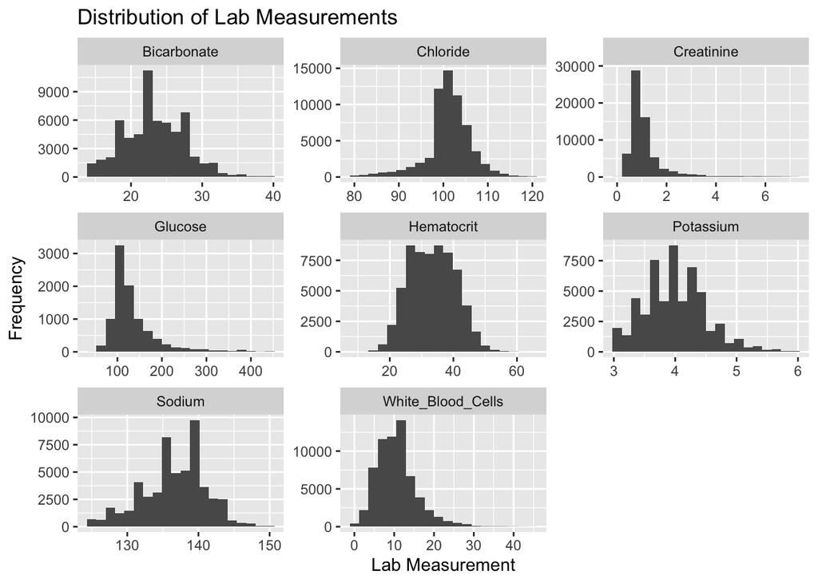

```r
ggplot(lab_measurements_long, aes(x = value)) +
  geom_histogram(bins = 20) +
  facet_wrap(~lab, scales = "free") +
  labs(x = "Lab Measurement", y = "Frequency") +
  ggtitle("Distribution of Lab Measurements")
```

```r
skewness_labs <- lab_measurements_long %>%
  group_by(lab) %>%
  summarise(skewness = skewness(value, na.rm = TRUE))
print(skewness_labs)
```

```
# A tibble: 8 × 2
  lab               skewness
  <chr>                <dbl>
1 Bicarbonate          0.249
2 Chloride            -0.902
3 Creatinine           3.35
4 Glucose              2.39
5 Hematocrit           0.112
6 Potassium            0.523
7 Sodium              -0.375
8 White_Blood_Cells    1.12
```

```r
# check for skewed data to apply log to numerical variables (vitals)
vitals <- mimiciv_icu_cohort_preprocessed |>
  select(
    subject_id, stay_id, Non_Invasive_BP_diastolic,
    Non_Invasive_BP_systolic, Temperature_Fahrenheit,
    Respiratory_Rate, Heart_Rate
  )

vitals_long <- vitals |>
  pivot_longer(
    cols = -c(subject_id, stay_id), names_to = "vitals",
    values_to = "value"
  ) |>
  print(width = Inf)
```

```
# A tibble: 320,430 × 4
   subject_id  stay_id vitals                    value
        <int>    <int> <chr>                     <dbl>
 1   10000032 39553978 Non_Invasive_BP_diastolic  48
 2   10000032 39553978 Non_Invasive_BP_systolic   84
 3   10000032 39553978 Temperature_Fahrenheit     98.7
 4   10000032 39553978 Respiratory_Rate           24
 5   10000032 39553978 Heart_Rate                 91
 6   10000980 39765666 Non_Invasive_BP_diastolic  77
 7   10000980 39765666 Non_Invasive_BP_systolic  150
 8   10000980 39765666 Temperature_Fahrenheit     98
 9   10000980 39765666 Respiratory_Rate           23
10   10000980 39765666 Heart_Rate                 77
# ℹ 320,420 more rows
```

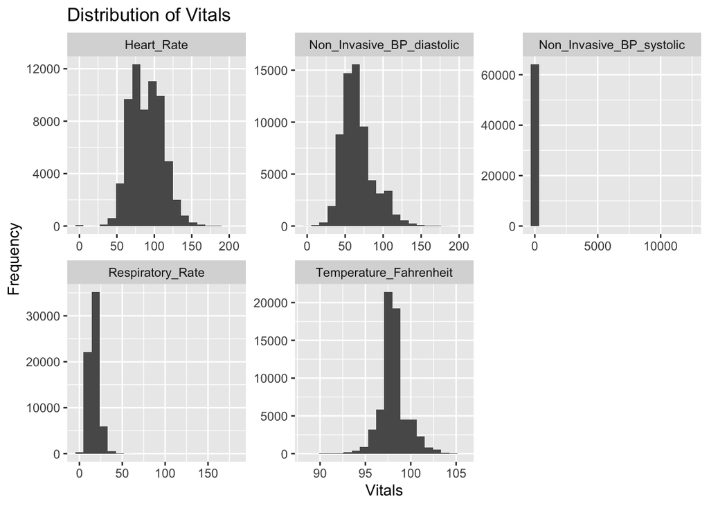

```r
ggplot(vitals_long, aes(x = value)) +
  geom_histogram(bins = 20) +
  facet_wrap(~vitals, scales = "free") +
  labs(x = "Vitals", y = "Frequency") +
  ggtitle("Distribution of Vitals")
```

```r
skewness_vitals <- vitals_long %>%
  group_by(vitals) %>%
  summarise(skewness = skewness(value, na.rm = TRUE))
print(skewness_vitals)
```

```
# A tibble: 5 × 2
  vitals                    skewness
  <chr>                        <dbl>
1 Heart_Rate                   0.210
2 Non_Invasive_BP_diastolic    1.01
3 Non_Invasive_BP_systolic   197.
4 Respiratory_Rate             2.75
5 Temperature_Fahrenheit       0.308
```

```r
# Apply log transformation to skewed data (for loop) if skewedness > abs(0.5)
mimiciv_icu_cohort_preprocessed <- mimiciv_icu_cohort_preprocessed |>
  mutate(
    # Bicarbonate = log(Bicarbonate + 1),
    Chloride = log(Chloride + 1),
    Creatinine = log(Creatinine + 1),
    Glucose = log(Glucose + 1),
    # Hematocrit = log(Hematocrit + 1),
    Potassium = log(Potassium + 1),
    # Sodium = log(Sodium + 1),
    White_Blood_Cells = log(White_Blood_Cells + 1),
    Non_Invasive_BP_diastolic = log(Non_Invasive_BP_diastolic + 1),
    Non_Invasive_BP_systolic = log(Non_Invasive_BP_systolic + 1),
    Temperature_Fahrenheit = log(Temperature_Fahrenheit + 1),
    Respiratory_Rate = log(Respiratory_Rate + 1),
    Heart_Rate = log(Heart_Rate + 1)
  )

mimiciv_icu_cohort_preprocessed
```

```
# A tibble: 64,086 × 22
   subject_id hadm_id stay_id gender age_at_intime marital_status race  los_long
        <int>   <int>   <int> <fct>          <int> <chr>          <fct> <fct>
 1   10000032  2.91e7  3.96e7 F                 52 WIDOWED        WHITE short
 2   10000980  2.69e7  3.98e7 F                 76 MARRIED        BLACK short
 3   10001217  2.46e7  3.46e7 F                 55 MARRIED        WHITE short
 4   10001217  2.77e7  3.46e7 F                 55 MARRIED        WHITE short
 5   10001884  2.62e7  3.75e7 F                 77 MARRIED        BLACK long
 6   10002013  2.36e7  3.91e7 F                 57 SINGLE         Other short
 7   10002155  2.03e7  3.11e7 F                 83 MARRIED        WHITE short
 8   10002155  2.38e7  3.11e7 F                 81 MARRIED        WHITE long
 9   10002155  2.90e7  3.11e7 F                 82 MARRIED        WHITE long
10   10002348  2.27e7  3.26e7 F                 77 SINGLE         WHITE long
# ℹ 64,076 more rows
# ℹ 14 more variables: first_careunit <fct>, Bicarbonate <dbl>,
#   Potassium <dbl>, Chloride <dbl>, Glucose <dbl>, Creatinine <dbl>,
#   Hematocrit <dbl>, Sodium <dbl>, White_Blood_Cells <dbl>,
#   Non_Invasive_BP_diastolic <dbl>, Non_Invasive_BP_systolic <dbl>,
#   Temperature_Fahrenheit <dbl>, Respiratory_Rate <dbl>, Heart_Rate <dbl>
```

#### One Hot Encoding

To handle categorical variables, I used one hot encoding. I performed one hot encoding on `marital_status`, `race`, and `first_careunit`.

```r
# One Hot Encoding
# GENDER
mimiciv_icu_cohort_preprocessed <- mimiciv_icu_cohort_preprocessed |>
  mutate(
    married = ifelse(marital_status == "MARRIED", 1, 0),
    single = ifelse(marital_status == "SINGLE", 1, 0),
    widowed = ifelse(marital_status == "WIDOWED", 1, 0),
    divorced = ifelse(marital_status == "DIVORCED", 1, 0)
  ) |>
  select(-marital_status)

# shorter way
# mimiciv_icu_cohort_preprocessed |>
#   mutate(value = 1) |>
#   pivot_wider(names_from = marital_status, values_from = value, values_fill
# = 0)

# RACE
mimiciv_icu_cohort_preprocessed <- mimiciv_icu_cohort_preprocessed |>
  mutate(
    asian = ifelse(race == "ASIAN", 1, 0),
    black = ifelse(race == "BLACK", 1, 0),
    white = ifelse(race == "WHITE", 1, 0),
    hispanic = ifelse(race == "HISPANIC", 1, 0),
    other_race = ifelse(race == "Other", 1, 0)
  ) |>
  select(-race)

# FIRST CAREUNIT
mimiciv_icu_cohort_preprocessed <- mimiciv_icu_cohort_preprocessed |>
  mutate(
    micu = ifelse(
      first_careunit == "Medical Intensive Care Unit (MICU) ", 1, 0
    ),
    sicu = ifelse(
      first_careunit == "Surgical Intensive Care Unit (SICU)", 1, 0
    ),
    msicu = ifelse(
      first_careunit == "Medical/Surgical Intensive Care Unit (MICU/SICU)", 1, 0
    ),
    cvicu = ifelse(
      first_careunit == "Cardiac Vascular Intensive Care Unit (CVICU)", 1, 0
    ),
    other_careunit = ifelse(
      first_careunit == "Other", 1, 0
    )
  ) |>
  select(-first_careunit)


mimiciv_icu_cohort_preprocessed |> print(width = Inf)
```

```
# A tibble: 64,086 × 33
   subject_id  hadm_id  stay_id gender age_at_intime los_long Bicarbonate
        <int>    <int>    <int> <fct>          <int> <fct>          <dbl>
 1   10000032 29079034 39553978 F                 52 short             25
 2   10000980 26913865 39765666 F                 76 short             21
 3   10001217 24597018 34592300 F                 55 short             22
 4   10001217 27703517 34592300 F                 55 short             22
 5   10001884 26184834 37510196 F                 77 long              30
 6   10002013 23581541 39060235 F                 57 short             24
 7   10002155 20345487 31090461 F                 83 short             23
 8   10002155 23822395 31090461 F                 81 long              23
 9   10002155 28994087 31090461 F                 82 long              23
10   10002348 22725460 32610785 F                 77 long              22
   Potassium Chloride Glucose Creatinine Hematocrit Sodium White_Blood_Cells
       <dbl>    <dbl>   <dbl>      <dbl>      <dbl>  <dbl>             <dbl>
```

[output cut: 47 more lines]

#### Creating New Features

Reviewing the exploratory data analysis (EDA) from hw3, I observed which features could be important for predicting long ICU stays. I did further research and gathered domain knowledge to understand the normal ranges for some lab measurements and vitals, and to create new features with demographic information that could be useful for the model.

I created new ratio features by dividing certain lab measurements by the patient’s age. I thought that this could be useful because some health measurements may differ by age. For example, a high creatine level relative to age could indicate kidney dysfunction. Since kidney function decreases with age, a high creatinine to age ratio could indicate that the patient has elevated creatinine levels for their age. Another example is the heart rate to age ratio. This metric can provide insights on the patient’s cardiovascular health relative to age and can be an important predictor of the patient’s length of stay. Two new variables were created: `creatinine_age_ratio` and `heart_rate_age_ratio`.

```r
# creatinine and age
mimiciv_icu_cohort_preprocessed <- mimiciv_icu_cohort_preprocessed |>
  mutate(creatinine_age_ratio = Creatinine / age_at_intime)
# low ratio is good

# heart rate and age
mimiciv_icu_cohort_preprocessed <- mimiciv_icu_cohort_preprocessed |>
  mutate(heart_rate_age_ratio = Heart_Rate / age_at_intime)
# low ratio is good
```

Seeing that `Hematocrit` was a key feature in the importance plot, I went back and created a new variable called, `normal_hematocrit`, to indicate if the levels of hematocrit is above or below a normal healthy threshold.

After researching the normal ranges for Hematocrit, I learned that the normal range for Hematocrit is 40-53% for men and 36-48% for women. Thus, I created a new variable to indicate if the Hematocrit level was outside of this healthy range or not, depending on their gender. A severely low Hematocrit level (~25%) could indicate blood loss, dehydration, or anemia, while a severely high Hematocrit level (~55%) could indicate dehydration or polycythemia.

[figure not shown]

```r
# EDA hematocrit and gender
mimiciv_icu_cohort_preprocessed |>
  ggplot(aes(x = los_long, y = White_Blood_Cells, color = factor(gender))) +
  geom_boxplot() +
  labs(
    title = "Hematocrit vs Length of Stay",
    x = "Length of Stay",
    y = "Hematocrit"
  )
```

```r
# mimiciv_icu_cohort_preprocessed$Hematocrit
```

```r
# Create new var for Hematocrit

normal_range_female <- c(36, 48)
normal_range_male <- c(40, 53)

mimiciv_icu_cohort_preprocessed <- mimiciv_icu_cohort_preprocessed |>
  mutate(
    normal_hematocrit = ifelse(
      gender == "F" & Hematocrit >= normal_range_female[1] &
        Hematocrit <= normal_range_female[2],
      0, # Within Normal Range for Female
      ifelse(
        gender == "M" & Hematocrit >= normal_range_male[1] &
          Hematocrit <= normal_range_male[2],
        0, # Within Normal Range for Male
        1 # Not Healthy (Outside Normal Range)
      )
    )
  )
mimiciv_icu_cohort_preprocessed$normal_hematocrit |> table()
```

```
    0     1
17409 45530
```

### 2. Split Data

2. Partition data into 50% training set and 50% test set. Stratify partitioning according to `los_long`. For grading purpose, sort the data by `subject_id`, `hadm_id`, and `stay_id` and use the seed `203` for the initial data split. Below is the sample code.

```r
# set.seed(203)
#
# # sort
# mimiciv_icu_cohort <- mimiciv_icu_cohort |>
#   arrange(subject_id, hadm_id, stay_id)
#
# data_split <- initial_split(
#   mimiciv_icu_cohort,
#   # stratify by los_long
#   strata = "los_long",
#   prop = 0.5
#   )
#
# data_split
```

```r
# Partitioning the data
table(mimiciv_icu_cohort_preprocessed$los_long)
```

```
short  long
33272 30814
```

```r
# set seed for reproducibility
set.seed(203)

# sort
mimiciv_icu_cohort_preprocessed <- mimiciv_icu_cohort_preprocessed |>
  arrange(subject_id, hadm_id, stay_id)

data_split <- initial_split(
  mimiciv_icu_cohort_preprocessed,
  # stratify by los_long
  strata = "los_long",
  prop = 0.5
)

data_split
```

```
<Training/Testing/Total>
<32043/32043/64086>
```

```r
# training set
train <- training(data_split) |>
  arrange(subject_id, hadm_id, stay_id)
# test set
test <- testing(data_split) |>
  arrange(subject_id, hadm_id, stay_id)
levels(train$los_long)
```

```
[1] "short" "long"
```

```r
levels(test$los_long)
```

```
[1] "short" "long"
```

```r
# arrange the data again for grading purposes
train
```

```
# A tibble: 32,043 × 36
   subject_id  hadm_id  stay_id gender age_at_intime los_long Bicarbonate
        <int>    <int>    <int> <fct>          <int> <fct>          <dbl>
 1   10001884 26184834 37510196 F                 77 long              30
 2   10002013 23581541 39060235 F                 57 short             24
 3   10002155 23822395 31090461 F                 81 long              23
 4   10002428 28662225 33987268 F                 81 long              25
 5   10002430 26295318 38392119 M                 90 long              23
 6   10002443 21329021 35044219 M                 53 long              18
 7   10002760 28094813 31831386 M                 56 short             29
 8   10002930 25922998 35629889 F                 53 short             16
 9   10003400 20214994 32128372 F                 75 long              15
10   10003400 23559586 32128372 F                 75 long              15
# ℹ 32,033 more rows
# ℹ 29 more variables: Potassium <dbl>, Chloride <dbl>, Glucose <dbl>,
#   Creatinine <dbl>, Hematocrit <dbl>, Sodium <dbl>, White_Blood_Cells <dbl>,
#   Non_Invasive_BP_diastolic <dbl>, Non_Invasive_BP_systolic <dbl>,
#   Temperature_Fahrenheit <dbl>, Respiratory_Rate <dbl>, Heart_Rate <dbl>,
#   married <dbl>, single <dbl>, widowed <dbl>, divorced <dbl>, asian <dbl>,
#   black <dbl>, white <dbl>, hispanic <dbl>, other_race <dbl>, micu <dbl>, …
```

```r
test
```

```
# A tibble: 32,043 × 36
   subject_id  hadm_id  stay_id gender age_at_intime los_long Bicarbonate
        <int>    <int>    <int> <fct>          <int> <fct>          <dbl>
 1   10000032 29079034 39553978 F                 52 short             25
 2   10000980 26913865 39765666 F                 76 short             21
 3   10001217 24597018 34592300 F                 55 short             22
 4   10001217 27703517 34592300 F                 55 short             22
 5   10002155 20345487 31090461 F                 83 short             23
 6   10002155 28994087 31090461 F                 82 long              23
 7   10002348 22725460 32610785 F                 77 long              22
 8   10002428 20321825 33987268 F                 81 long              25
 9   10002428 23473524 33987268 F                 81 long              25
10   10002428 28662225 33987268 F                 81 long              25
# ℹ 32,033 more rows
# ℹ 29 more variables: Potassium <dbl>, Chloride <dbl>, Glucose <dbl>,
#   Creatinine <dbl>, Hematocrit <dbl>, Sodium <dbl>, White_Blood_Cells <dbl>,
#   Non_Invasive_BP_diastolic <dbl>, Non_Invasive_BP_systolic <dbl>,
#   Temperature_Fahrenheit <dbl>, Respiratory_Rate <dbl>, Heart_Rate <dbl>,
#   married <dbl>, single <dbl>, widowed <dbl>, divorced <dbl>, asian <dbl>,
#   black <dbl>, white <dbl>, hispanic <dbl>, other_race <dbl>, micu <dbl>, …
```

```r
# Split Data - My Way
# set.seed(203)
# mimiciv_icu_cohort_preprocessed <- mimiciv_icu_cohort_preprocessed |>
#   arrange(subject_id, hadm_id, stay_id)
#
# train = mimiciv_icu_cohort_preprocessed %>% sample_frac(0.5) |>
#   arrange(subject_id, hadm_id, stay_id)
# test = mimiciv_icu_cohort_preprocessed %>% setdiff(train) |>
#   arrange(subject_id, hadm_id, stay_id)
#
# levels(train$los_long)
# levels(test$los_long)
#
# train
# test
```

### 3. Training and Tuning

3. Train and tune the models using the training set.

#### Logistic Regression with Elastic Net

```r
# Logistic Regression with
logit_recipe <- recipe(
  los_long ~ .,
  data = train
) |>
  # HANDLE MISSING VALUES
  step_impute_mean(all_numeric(), -all_outcomes()) |>
  # step_meanimpute will impute missing values with the mean of the training set
  # for all numeric variables except the outcome variable (los_long)
  # step_impute_mode(marital_status) |>
  step_impute_mode(all_nominal_predictors(), -all_outcomes()) |>
  # use mode for categorical
  step_mutate_at(all_logical(), fn = list(~ factor(.))) |>
  # convert any logical var to factor
  # zero variance
  step_dummy(all_nominal_predictors()) |>
  # dummy not needed for random forest
  step_zv(all_numeric_predictors()) |>
  # center and scale
  step_normalize(all_numeric_predictors())

# Create a model specification
logit_mod <-
  logistic_reg(
    penalty = tune(),
    mixture = tune()
  ) |>
  set_engine("glmnet", standardize = FALSE) |>
  print()
```

```
Logistic Regression Model Specification (classification)

Main Arguments:
  penalty = tune()
  mixture = tune()

Engine-Specific Arguments:
  standardize = FALSE

Computational engine: glmnet
```

```r
# Bundle the recipe and model into a workflow
logit_wf <- workflow() |>
  add_recipe(logit_recipe) |>
  add_model(logit_mod) |>
  print()
```

```
══ Workflow ════════════════════════════════════════════════════════════════════
Preprocessor: Recipe
Model: logistic_reg()

── Preprocessor ────────────────────────────────────────────────────────────────
6 Recipe Steps

• step_impute_mean()
• step_impute_mode()
• step_mutate_at()
• step_dummy()
• step_zv()
• step_normalize()

── Model ───────────────────────────────────────────────────────────────────────
Logistic Regression Model Specification (classification)

Main Arguments:
  penalty = tune()
  mixture = tune()

Engine-Specific Arguments:
  standardize = FALSE

Computational engine: glmnet
```

```r
# Tune
logit_grid <- grid_regular(
  penalty(range = c(-6, 3)),
  mixture(),
  levels = c(100, 5)
) |>
  print()
```

```
# A tibble: 500 × 2
      penalty mixture
        <dbl>   <dbl>
 1 0.000001         0
 2 0.00000123       0
 3 0.00000152       0
 4 0.00000187       0
 5 0.00000231       0
 6 0.00000285       0
 7 0.00000351       0
 8 0.00000433       0
 9 0.00000534       0
10 0.00000658       0
# ℹ 490 more rows
```

```r
# Cross-validation
set.seed(212)
logit_vfold <- vfold_cv(train, v = 5, strata = los_long)
```

```r
# Using foreach parallel
num_cores <- detectCores() - 2
# leave 2 cores for other systems and processes
# print(num_cores) 8-2=6
registerDoParallel(cores = num_cores)
# #Fit C-V

system.time(
  logit_fit <- logit_wf %>%
    tune_grid(
      resamples = logit_vfold,
      grid = logit_grid,
      metrics = metric_set(roc_auc, accuracy)
    )
)
```

```
   user  system elapsed
 34.540   2.336   7.757
```

```r
# Print the results
logit_fit
```

```
# Tuning results
# 5-fold cross-validation using stratification
# A tibble: 5 × 4
  splits               id    .metrics             .notes
  <list>               <chr> <list>               <list>
1 <split [25633/6410]> Fold1 <tibble [1,000 × 6]> <tibble [0 × 3]>
2 <split [25634/6409]> Fold2 <tibble [1,000 × 6]> <tibble [0 × 3]>
3 <split [25635/6408]> Fold3 <tibble [1,000 × 6]> <tibble [0 × 3]>
4 <split [25635/6408]> Fold4 <tibble [1,000 × 6]> <tibble [0 × 3]>
5 <split [25635/6408]> Fold5 <tibble [1,000 × 6]> <tibble [0 × 3]>
```

```r
stopImplicitCluster()

#   user  system elapsed
#  35.485  17.927  16.097
```

```
# A tibble: 1,000 × 8
      penalty mixture .metric  .estimator  mean     n std_err
        <dbl>   <dbl> <chr>    <chr>      <dbl> <int>   <dbl>
 1 0.000001         0 accuracy binary     0.570     5 0.00154
 2 0.000001         0 roc_auc  binary     0.595     5 0.00225
 3 0.00000123       0 accuracy binary     0.570     5 0.00154
 4 0.00000123       0 roc_auc  binary     0.595     5 0.00225
 5 0.00000152       0 accuracy binary     0.570     5 0.00154
 6 0.00000152       0 roc_auc  binary     0.595     5 0.00225
 7 0.00000187       0 accuracy binary     0.570     5 0.00154
 8 0.00000187       0 roc_auc  binary     0.595     5 0.00225
 9 0.00000231       0 accuracy binary     0.570     5 0.00154
10 0.00000231       0 roc_auc  binary     0.595     5 0.00225
   .config
   <chr>
 1 Preprocessor1_Model001
 2 Preprocessor1_Model001
 3 Preprocessor1_Model002
 4 Preprocessor1_Model002
 5 Preprocessor1_Model003
 6 Preprocessor1_Model003
 7 Preprocessor1_Model004
 8 Preprocessor1_Model004
 9 Preprocessor1_Model005
10 Preprocessor1_Model005
# ℹ 990 more rows
```

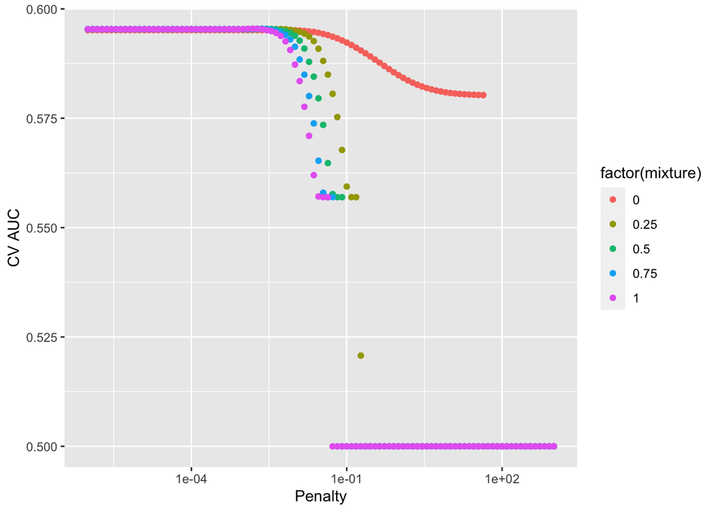

```r
# Visualize CV results
logit_fit |>
  # aggregate metrics from K folds
  collect_metrics() |>
  print(width = Inf) |>
  filter(.metric == "roc_auc") |>
  ggplot(mapping = aes(x = penalty, y = mean, color = factor(mixture))) +
  geom_point() +
  labs(x = "Penalty", y = "CV AUC") +
  scale_x_log10()
```

```r
logit_fit |>
  show_best("roc_auc")
```

```
# A tibble: 5 × 8
  penalty mixture .metric .estimator  mean     n std_err .config
    <dbl>   <dbl> <chr>   <chr>      <dbl> <int>   <dbl> <chr>
1 0.00231    0.75 roc_auc binary     0.595     5 0.00222 Preprocessor1_Model338
2 0.00152    1    roc_auc binary     0.595     5 0.00221 Preprocessor1_Model436
3 0.00187    0.75 roc_auc binary     0.595     5 0.00222 Preprocessor1_Model337
4 0.00187    1    roc_auc binary     0.595     5 0.00222 Preprocessor1_Model437
5 0.00285    0.5  roc_auc binary     0.595     5 0.00224 Preprocessor1_Model239
```

```r
best_logit_fit <- logit_fit |>
  select_best("roc_auc")
best_logit_fit
```

```
# A tibble: 1 × 3
  penalty mixture .config
    <dbl>   <dbl> <chr>
1 0.00231    0.75 Preprocessor1_Model338
```

```r
# Final workflow
final_logit_wf <- logit_wf |>
  finalize_workflow(best_logit_fit)

# Fit the whole training set, then predict the TEST cases
final_logit_fit <-
  final_logit_wf |>
  last_fit(data_split)
final_logit_fit
```

```
# Resampling results
# Manual resampling
# A tibble: 1 × 6
  splits                id             .metrics .notes   .predictions .workflow
  <list>                <chr>          <list>   <list>   <list>       <list>
1 <split [32043/32043]> train/test sp… <tibble> <tibble> <tibble>     <workflow>
```

```r
# Test metrics
final_logit_fit |>
  collect_metrics()
```

```
# A tibble: 2 × 4
  .metric  .estimator .estimate .config
  <chr>    <chr>          <dbl> <chr>
1 accuracy binary         0.571 Preprocessor1_Model1
2 roc_auc  binary         0.600 Preprocessor1_Model1
```

Note: the following two code chunks are meant to only be run to save the model with the highest accuracy and AUROC into an RDS file. Scores produced in the rendered output may differ from the ones saved in the RDS file.

The first should only be run once to initialize the values. Set eval = TRUE if you would like to save and load the newly generated models into RDS files.

```r
# ONLY RUN ONCE TO INITIALIZE VALUES!
# comment out after to avoid overwriting
highest_logit_accuracy <- 0
highest_logit_auroc <- 0
logit_accuracy_list <- c()
logit_auroc_list <- c()
```

```r
# Save best logistic regression model

logit_accuracy <- final_logit_fit %>%
  collect_metrics() %>%
  filter(.metric == "accuracy") %>%
  pull(.estimate)
logit_accuracy

logit_auroc <- final_logit_fit %>%
  collect_metrics() %>%
  filter(.metric == "roc_auc") %>%
  pull(.estimate)
logit_auroc

# only replace if higher accuracy/roc
if (logit_accuracy > highest_logit_accuracy) {
  saveRDS(final_logit_fit, "final_logit_fit_accuracy.rds")
  highest_logit_accuracy <- logit_accuracy
  cat("Highest Accuracy:", highest_logit_accuracy, "\n")
  # keep track of history of accuracy
  logit_accuracy_list <- c(logit_accuracy_list, logit_accuracy)
}

if (logit_auroc > highest_logit_auroc) {
  saveRDS(final_logit_fit, "final_logit_fit_auroc.rds")
  highest_logit_auroc <- logit_auroc
  cat("Highest AUROC:", highest_logit_auroc, "\n")
  # keep track of history of accuracy and auroc
  logit_auroc_list <- c(logit_auroc_list, logit_auroc)
}
```

Highest Accuracy: 0.5741035 Highest AUROC: 0.6028710

Note: set `eval==TRUE` and uncomment below to load the best logistic regression model from the RDS file.

```r
# Load best logistic regression model RDS
# logit_rds_acc <- readRDS("final_logit_fit_accuracy.rds")
# logit_rds_auroc <- readRDS("final_logit_fit_auroc.rds")
```

#### Random Forest

```r
# Random Forest recipe
rf_recipe <- recipe(
  los_long ~ .,
  data = train
) |>
  # step_dummy(all_nominal()) |>
  # dummy not needed for random forest
  # HANDLE MISSING VALUES
  step_impute_mean(all_numeric(), -all_outcomes()) |>
  # step_meanimpute will impute missing values with the mean of the training set
  # for all numeric variables except the outcome variable (los_long)
  step_impute_mode(all_nominal_predictors(), -all_outcomes()) |>
  # use mode for categorical
  # zero variance
  step_zv(all_numeric_predictors())
# step_normalize(all_numeric_predictors())
# center and scale not needed for rf
# step_mutate(los_long = factor(los_long, levels = c("short", "long")))

# Create a model specification
rf_mod <- rand_forest(
  mode = "classification",
  mtry = tune(),
  # trees = tune(),
  trees = tune()
) |>
  # importance = TRUE) |>
  set_engine("ranger", importance = "impurity")

rf_mod
```

```
Random Forest Model Specification (classification)

Main Arguments:
  mtry = tune()
  trees = tune()

Engine-Specific Arguments:
  importance = impurity

Computational engine: ranger
```

```r
# Bundle the recipe and model into a workflow
rf_wf <- workflow() %>%
  add_recipe(rf_recipe) %>%
  add_model(rf_mod)

# Tune
rf_grid <- grid_regular(
  trees(range = c(100L, 300L)),
  mtry(range = c(1L, 5L)),
  levels = c(3, 5)
)
rf_grid
```

```
# A tibble: 15 × 2
   trees  mtry
   <int> <int>
 1   100     1
 2   200     1
 3   300     1
 4   100     2
 5   200     2
 6   300     2
 7   100     3
 8   200     3
 9   300     3
10   100     4
11   200     4
12   300     4
13   100     5
14   200     5
15   300     5
```

```r
# Cross-validation
set.seed(212)
rf_vfold <- vfold_cv(train, v = 5, strata = los_long)
```

```r
# Using foreach parallel
num_cores <- detectCores() - 2
registerDoParallel(cores = num_cores)

# Fit C-V
system.time(
  rf_fit <- rf_wf %>%
    tune_grid(
      resamples = rf_vfold,
      grid = rf_grid,
      metrics = metric_set(roc_auc, accuracy)
    )
)
```

```
   user  system elapsed
596.772   7.366 113.965
```

```r
# Print the results
rf_fit
```

```
# Tuning results
# 5-fold cross-validation using stratification
# A tibble: 5 × 4
  splits               id    .metrics          .notes
  <list>               <chr> <list>            <list>
1 <split [25633/6410]> Fold1 <tibble [30 × 6]> <tibble [0 × 3]>
2 <split [25634/6409]> Fold2 <tibble [30 × 6]> <tibble [0 × 3]>
3 <split [25635/6408]> Fold3 <tibble [30 × 6]> <tibble [0 × 3]>
4 <split [25635/6408]> Fold4 <tibble [30 × 6]> <tibble [0 × 3]>
5 <split [25635/6408]> Fold5 <tibble [30 × 6]> <tibble [0 × 3]>
```

```r
stopImplicitCluster()

# user  system elapsed
# 502.885  16.658 181.793
# 408.261  18.776 148.661  updated reduced time
```

```
# A tibble: 30 × 8
    mtry trees .metric  .estimator  mean     n std_err .config
   <int> <int> <chr>    <chr>      <dbl> <int>   <dbl> <chr>
 1     1   100 accuracy binary     0.575     5 0.00213 Preprocessor1_Model01
 2     1   100 roc_auc  binary     0.609     5 0.00219 Preprocessor1_Model01
 3     1   200 accuracy binary     0.575     5 0.00204 Preprocessor1_Model02
 4     1   200 roc_auc  binary     0.612     5 0.00195 Preprocessor1_Model02
 5     1   300 accuracy binary     0.576     5 0.00241 Preprocessor1_Model03
 6     1   300 roc_auc  binary     0.613     5 0.00162 Preprocessor1_Model03
 7     2   100 accuracy binary     0.575     5 0.00190 Preprocessor1_Model04
 8     2   100 roc_auc  binary     0.601     5 0.00153 Preprocessor1_Model04
 9     2   200 accuracy binary     0.577     5 0.00264 Preprocessor1_Model05
10     2   200 roc_auc  binary     0.605     5 0.00152 Preprocessor1_Model05
# ℹ 20 more rows
```

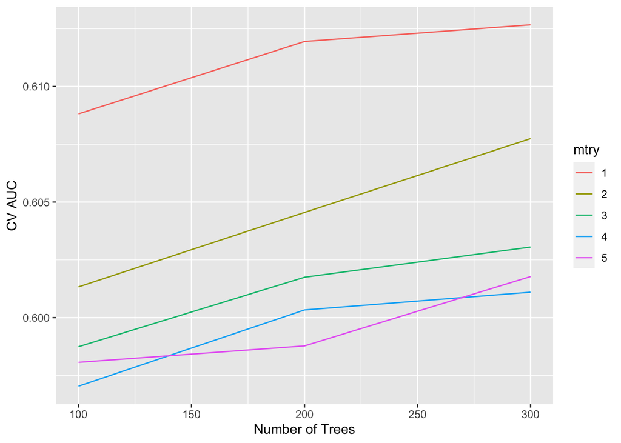

```r
rf_fit %>%
  collect_metrics() %>%
  print(width = Inf) %>%
  filter(.metric == "roc_auc") %>%
  mutate(mtry = as.factor(mtry)) %>%
  ggplot(mapping = aes(x = trees, y = mean, color = mtry)) +
  # geom_point() +
  geom_line() +
  labs(x = "Number of Trees", y = "CV AUC")
```

```r
rf_fit |>
  show_best("roc_auc")
```

```
# A tibble: 5 × 8
   mtry trees .metric .estimator  mean     n std_err .config
  <int> <int> <chr>   <chr>      <dbl> <int>   <dbl> <chr>
1     1   300 roc_auc binary     0.613     5 0.00162 Preprocessor1_Model03
2     1   200 roc_auc binary     0.612     5 0.00195 Preprocessor1_Model02
3     1   100 roc_auc binary     0.609     5 0.00219 Preprocessor1_Model01
4     2   300 roc_auc binary     0.608     5 0.00127 Preprocessor1_Model06
5     2   200 roc_auc binary     0.605     5 0.00152 Preprocessor1_Model05
```

```r
best_rf_fit <- rf_fit |>
  select_best("roc_auc")
best_rf_fit
```

```
# A tibble: 1 × 3
   mtry trees .config
  <int> <int> <chr>
1     1   300 Preprocessor1_Model03
```

```r
# Final workflow
final_wf_rf <- rf_wf |>
  finalize_workflow(best_rf_fit)

# Fit the whole training set, then predict the test cases
final_fit_rf <-
  final_wf_rf |>
  last_fit(data_split)
final_fit_rf
```

```
# Resampling results
# Manual resampling
# A tibble: 1 × 6
  splits                id             .metrics .notes   .predictions .workflow
  <list>                <chr>          <list>   <list>   <list>       <list>
1 <split [32043/32043]> train/test sp… <tibble> <tibble> <tibble>     <workflow>
```

```r
# Test metrics
final_fit_rf |>
  collect_metrics()
```

```
# A tibble: 2 × 4
  .metric  .estimator .estimate .config
  <chr>    <chr>          <dbl> <chr>
1 accuracy binary         0.579 Preprocessor1_Model1
2 roc_auc  binary         0.620 Preprocessor1_Model1
```

Note: the following two code chunks are meant to only be run to save the model with the highest accuracy and AUROC into an RDS file. Scores produced in the rendered output may differ from the ones saved in the RDS file.

The first should only be run once to initialize the values. Set eval = TRUE if you would like to save and load the newly generated models into RDS files.

```r
# ONLY RUN ONCE TO INITIALIZE VALUES!
# comment out after to avoid overwriting
highest_rf_accuracy <- 0
highest_rf_auroc <- 0
rf_accuracy_list <- c()
rf_auroc_list <- c()
```

```r
# Save best random forest model

rf_accuracy <- final_fit_rf %>%
  collect_metrics() %>%
  filter(.metric == "accuracy") %>%
  pull(.estimate)
rf_accuracy

rf_auroc <- final_fit_rf %>%
  collect_metrics() %>%
  filter(.metric == "roc_auc") %>%
  pull(.estimate)
rf_auroc


# only replace if higher accuracy/roc
if (rf_accuracy > highest_rf_accuracy) {
  saveRDS(final_fit_rf, "final_rf_fit_accuracy.rds")
  highest_rf_accuracy <- rf_accuracy
  cat("Highest Accuracy:", highest_rf_accuracy, "\n")
  # keep track of history of accuracy
  rf_accuracy_list <- c(rf_accuracy_list, rf_accuracy)
}

if (rf_auroc > highest_rf_auroc) {
  saveRDS(final_fit_rf, "final_rf_fit_auroc.rds")
  highest_rf_auroc <- rf_auroc
  cat("Highest AUROC:", highest_rf_auroc, "\n")
  # keep track of history of accuracy and auroc
  rf_auroc_list <- c(rf_auroc_list, rf_auroc)
}
```

Highest Accuracy: 0.5816559 Highest AUROC: 0.6234321

Note: set `eval==TRUE` and uncomment below to load the best random forest model from the RDS file.

```r
# Load best logistic regression model RDS
# rf_rds_acc <- readRDS("final_rf_fit_accuracy.rds")
# rf_rds_auroc <- readRDS("final_rf_fit_auroc.rds")
```

#### Boosting

```r
# Boosting recipe
gb_recipe <- recipe(
  los_long ~ .,
  data = train
) |>
  # HANDLE MISSING VALUES
  step_impute_mean(all_numeric(), -all_outcomes()) |>
  # step_meanimpute will impute missing values with the mean of the training set
  # for all numeric variables except the outcome variable (los_long)
  # step_impute_mode(marital_status) |>
  step_impute_mode(all_nominal_predictors(), -all_outcomes()) |>
  # use mode for categorical
  step_dummy(all_nominal_predictors()) |>
  # create traditional dummy variables (necessary for xgboost)
  step_zv(all_numeric_predictors())
# zero variance
# step_mutate(los_long = factor(los_long, levels = c("short", "long")))

# Create a model specification
gb_mod <-
  boost_tree(
    mode = "classification",
    trees = 500, # reduce trees for faster tuning
    # trees = 500, # reduce for faster tuning
    tree_depth = tune(),
    learn_rate = tune()
  ) |>
  set_engine("xgboost")
gb_mod
```

```
Boosted Tree Model Specification (classification)

Main Arguments:
  trees = 500
  tree_depth = tune()
  learn_rate = tune()

Computational engine: xgboost
```

```r
# Bundle the recipe and model into a workflow
gb_wf <- workflow() |>
  add_recipe(gb_recipe) |>
  add_model(gb_mod)
gb_wf
```

```
══ Workflow ════════════════════════════════════════════════════════════════════
Preprocessor: Recipe
Model: boost_tree()

── Preprocessor ────────────────────────────────────────────────────────────────
4 Recipe Steps

• step_impute_mean()
• step_impute_mode()
• step_dummy()
• step_zv()

── Model ───────────────────────────────────────────────────────────────────────
Boosted Tree Model Specification (classification)

Main Arguments:
  trees = 500
  tree_depth = tune()
  learn_rate = tune()

Computational engine: xgboost
```

```r
# Tune
gb_grid <- grid_regular(
  tree_depth(range = c(1L, 3L)),
  learn_rate(range = c(-3, 2), trans = log10_trans()),
  # levels = c(3, 5) # reduced levels
  levels = c(2, 3) # reduce levels for faster tuning
)
gb_grid
```

```
# A tibble: 6 × 2
  tree_depth learn_rate
       <int>      <dbl>
1          1      0.001
2          3      0.001
3          1      0.316
4          3      0.316
5          1    100
6          3    100
```

```r
# Cross-validation
set.seed(212)
gb_vfold <- vfold_cv(train, v = 5, strata = los_long)
```

```r
# Using foreach parallel
num_cores <- detectCores() - 2
registerDoParallel(cores = num_cores)

system.time(
  gb_fit <- gb_wf |>
    tune_grid(
      resamples = gb_vfold,
      grid = gb_grid,
      metrics = metric_set(roc_auc, accuracy)
    )
)
```

```
   user  system elapsed
235.613   0.848  47.700
```

```r
gb_fit
```

```
# Tuning results
# 5-fold cross-validation using stratification
# A tibble: 5 × 4
  splits               id    .metrics          .notes
  <list>               <chr> <list>            <list>
1 <split [25633/6410]> Fold1 <tibble [12 × 6]> <tibble [0 × 3]>
2 <split [25634/6409]> Fold2 <tibble [12 × 6]> <tibble [0 × 3]>
3 <split [25635/6408]> Fold3 <tibble [12 × 6]> <tibble [0 × 3]>
4 <split [25635/6408]> Fold4 <tibble [12 × 6]> <tibble [0 × 3]>
5 <split [25635/6408]> Fold5 <tibble [12 × 6]> <tibble [0 × 3]>
```

```r
stopImplicitCluster()


# levels = c(3, 6)
#   user  system elapsed
# 833.504  10.397 475.504

# levels = c(2, 3)
# learn_rate(range = c(-3, 2) most updated!!
#   user  system elapsed
# 149.837   1.412  39.031
```

```
# A tibble: 12 × 8
   tree_depth learn_rate .metric  .estimator  mean     n std_err
        <int>      <dbl> <chr>    <chr>      <dbl> <int>   <dbl>
 1          1      0.001 accuracy binary     0.547     5 0.00250
 2          1      0.001 roc_auc  binary     0.556     5 0.00359
 3          3      0.001 accuracy binary     0.557     5 0.00310
 4          3      0.001 roc_auc  binary     0.579     5 0.00267
 5          1      0.316 accuracy binary     0.578     5 0.00317
 6          1      0.316 roc_auc  binary     0.609     5 0.00201
 7          3      0.316 accuracy binary     0.575     5 0.00144
 8          3      0.316 roc_auc  binary     0.600     5 0.00219
 9          1    100     accuracy binary     0.547     5 0.00249
10          1    100     roc_auc  binary     0.546     5 0.00254
11          3    100     accuracy binary     0.479     5 0.0181
12          3    100     roc_auc  binary     0.480     5 0.0182
   .config
   <chr>
 1 Preprocessor1_Model1
 2 Preprocessor1_Model1
 3 Preprocessor1_Model2
 4 Preprocessor1_Model2
 5 Preprocessor1_Model3
 6 Preprocessor1_Model3
 7 Preprocessor1_Model4
 8 Preprocessor1_Model4
 9 Preprocessor1_Model5
10 Preprocessor1_Model5
11 Preprocessor1_Model6
12 Preprocessor1_Model6
```

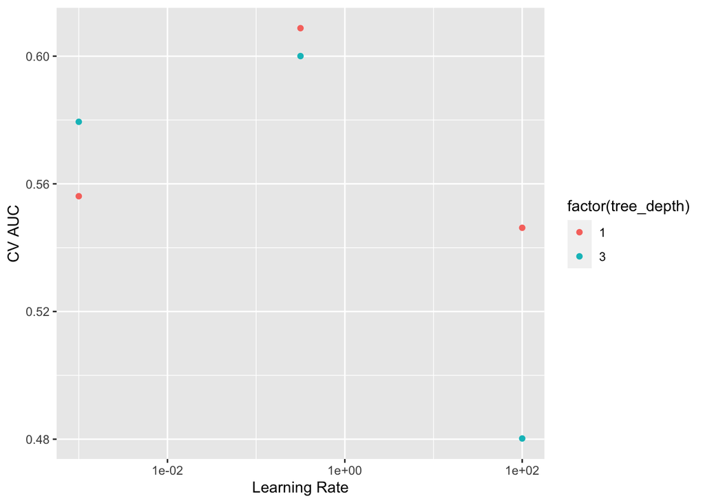

```r
gb_fit |>
  collect_metrics() |>
  print(width = Inf) |>
  filter(.metric == "roc_auc") |>
  ggplot(mapping = aes(x = learn_rate, y = mean, color = factor(tree_depth))) +
  geom_point() +
  labs(x = "Learning Rate", y = "CV AUC") +
  scale_x_log10()
```

```r
gb_fit |>
  show_best("roc_auc")
```

```
# A tibble: 5 × 8
  tree_depth learn_rate .metric .estimator  mean     n std_err .config
       <int>      <dbl> <chr>   <chr>      <dbl> <int>   <dbl> <chr>
1          1      0.316 roc_auc binary     0.609     5 0.00201 Preprocessor1_Mo…
2          3      0.316 roc_auc binary     0.600     5 0.00219 Preprocessor1_Mo…
3          3      0.001 roc_auc binary     0.579     5 0.00267 Preprocessor1_Mo…
4          1      0.001 roc_auc binary     0.556     5 0.00359 Preprocessor1_Mo…
5          1    100     roc_auc binary     0.546     5 0.00254 Preprocessor1_Mo…
```

```r
best_gb_fit <- gb_fit |>
  select_best("roc_auc")
best_gb_fit
```

```
# A tibble: 1 × 3
  tree_depth learn_rate .config
       <int>      <dbl> <chr>
1          1      0.316 Preprocessor1_Model3
```

```r
# Final workflow
final_wf_gb <- gb_wf |>
  finalize_workflow(best_gb_fit)

# Fit the whole training set, then predict the test cases
final_fit_gb <-
  final_wf_gb |>
  last_fit(data_split)

# Test metrics
final_fit_gb |>
  collect_metrics()
```

```
# A tibble: 2 × 4
  .metric  .estimator .estimate .config
  <chr>    <chr>          <dbl> <chr>
1 accuracy binary         0.584 Preprocessor1_Model1
2 roc_auc  binary         0.619 Preprocessor1_Model1
```

```r
# accuracy  binary  0.5851712   Preprocessor1_Model1
# roc_auc   binary  0.6191067   Preprocessor1_Model1
```

Note: the following two code chunks are meant to only be run to save the model with the highest accuracy and AUROC into an RDS file. Scores produced in the rendered output may differ from the ones saved in the RDS file.

The first should only be run once to initialize the values. Set eval = TRUE if you would like to save and load the newly generated models into RDS files.

```r
# ONLY RUN ONCE TO INITIALIZE VALUES!
# comment out after to avoid overwriting
highest_gb_accuracy <- 0
highest_gb_auroc <- 0
gb_accuracy_list <- c()
gb_auroc_list <- c()
```

```r
# Save best boosting model

gb_accuracy <- final_fit_gb %>%
  collect_metrics() %>%
  filter(.metric == "accuracy") %>%
  pull(.estimate)
gb_accuracy

gb_auroc <- final_fit_gb %>%
  collect_metrics() %>%
  filter(.metric == "roc_auc") %>%
  pull(.estimate)
gb_auroc

# only replace if higher accuracy/roc
if (gb_accuracy > highest_gb_accuracy) {
  saveRDS(final_fit_gb, "final_gb_fit_accuracy.rds")
  highest_gb_accuracy <- gb_accuracy
  cat("Highest Accuracy:", highest_gb_accuracy, "\n")
  # keep track of history of accuracy
  gb_accuracy_list <- c(gb_accuracy_list, gb_accuracy)
}

if (gb_auroc > highest_gb_auroc) {
  saveRDS(final_fit_gb, "final_gb_fit_auroc.rds")
  highest_gb_auroc <- gb_auroc
  cat("Highest AUROC:", highest_gb_auroc, "\n")
  # keep track of history of accuracy and auroc
  gb_auroc_list <- c(gb_auroc_list, gb_auroc)
}
```

Highest Accuracy: 0.5845895 Highest AUROC: 0.6194448

Note: set `eval==TRUE` and uncomment below to load the best boosting models from the RDS file.

```r
# Load best logistic regression model RDS
# gb_rds_acc <- readRDS("final_gb_fit_accuracy.rds")
# gb_rds_auroc <- readRDS("final_gb_fit_auroc.rds")
```

#### Multi-Layer Perceptron (MLP)

```r
# multi-layer perceptron (MLP)  recipe
mlp_recipe <- recipe(
  los_long ~ .,
  data = train
) |>
  # HANDLE MISSING VALUES
  step_impute_mean(all_numeric(), -all_outcomes()) |>
  # step_meanimpute will impute missing values with the mean of the training set
  # for all numeric variables except the outcome variable (los_long)
  # step_impute_mode(marital_status) |>
  # use mode for categorical
  step_impute_mode(all_nominal_predictors(), -all_outcomes()) |>
  # alternative way to do all categorical
  step_dummy(all_nominal_predictors()) |>
  # create dummy variables
  step_zv(all_numeric_predictors()) |>
  # zero variance
  step_normalize(all_numeric_predictors())
# center and scale numeric data
# step_mutate(los_long = factor(los_long, levels = c("short", "long")))

# Create a model specification
mlp_mod <-
  mlp(
    mode = "classification",
    hidden_units = tune(),
    # dropout = tune(),
    penalty = tune(), # Add regularization
    epochs = tune(),
  ) |>
  set_engine("nnet", verbose = 0)
mlp_mod
```

```
Single Layer Neural Network Model Specification (classification)

Main Arguments:
  hidden_units = tune()
  penalty = tune()
  epochs = tune()

Engine-Specific Arguments:
  verbose = 0

Computational engine: nnet
```

```r
# Bundle the recipe and model into a workflow
mlp_wf <- workflow() %>%
  add_recipe(mlp_recipe) %>%
  add_model(mlp_mod)

# Tune
# mlp_grid <- grid_regular(
#   hidden_units(range = c(1, 20)),
#   levels = 5
#   )
# mlp_grid

# simplified tuning grid
# mlp_grid <- grid_regular(
#   hidden_units(range = c(1, 10)), #reduced range
#   penalty = 2,
#   epochs = 10,
#   levels = 10
# )
# mlp_grid

mlp_grid <- grid_random(
  hidden_units() %>% range_set(c(1, 5)),
  penalty() %>% range_set(c(0.01, 0.1)),
  epochs() %>% range_set(c(5, 10)),
  size = 10
)
# dials changed its parameter objects to be functions instead of
# pre-compiled objects

# Cross-validation
set.seed(203)
mlp_vfold <- vfold_cv(train, v = 5, strata = los_long)
```

```r
# Using foreach parallel
num_cores <- detectCores() - 2
registerDoParallel(cores = num_cores)

# Fit the model
system.time(
  mlp_fit <- mlp_wf %>%
    tune_grid(
      resamples = mlp_vfold,
      grid = mlp_grid,
      metrics = metric_set(roc_auc, accuracy)
    )
)
```

```
   user  system elapsed
 20.380   0.741   4.345
```

```r
# Print the results
mlp_fit
```

```
# Tuning results
# 5-fold cross-validation using stratification
# A tibble: 5 × 4
  splits               id    .metrics          .notes
  <list>               <chr> <list>            <list>
1 <split [25633/6410]> Fold1 <tibble [20 × 7]> <tibble [0 × 3]>
2 <split [25634/6409]> Fold2 <tibble [20 × 7]> <tibble [0 × 3]>
3 <split [25635/6408]> Fold3 <tibble [20 × 7]> <tibble [0 × 3]>
4 <split [25635/6408]> Fold4 <tibble [20 × 7]> <tibble [0 × 3]>
5 <split [25635/6408]> Fold5 <tibble [20 × 7]> <tibble [0 × 3]>
```

```r
stopImplicitCluster()

# user  system elapsed
# 197.154   2.772  53.083

#  6.648   1.392   5.276 most updated!! simplified grid
```

```
# A tibble: 20 × 9
   hidden_units penalty epochs .metric  .estimator  mean     n std_err
          <int>   <dbl>  <int> <chr>    <chr>      <dbl> <int>   <dbl>
 1            5    1.26      7 accuracy binary     0.556     5 0.00799
 2            5    1.26      7 roc_auc  binary     0.573     5 0.0121
 3            2    1.19     10 accuracy binary     0.562     5 0.00317
 4            2    1.19     10 roc_auc  binary     0.579     5 0.00879
 5            5    1.10     10 accuracy binary     0.567     5 0.00116
 6            5    1.10     10 roc_auc  binary     0.592     5 0.00129
 7            3    1.06     10 accuracy binary     0.563     5 0.00236
 8            3    1.06     10 roc_auc  binary     0.588     5 0.00183
 9            1    1.04      7 accuracy binary     0.534     5 0.0185
10            1    1.04      7 roc_auc  binary     0.549     5 0.0300
11            1    1.19      7 accuracy binary     0.560     5 0.00383
12            1    1.19      7 roc_auc  binary     0.583     5 0.00449
```

[output cut: 30 more lines]

[figure not shown]

```r
# Visualize CV results
mlp_fit %>%
  collect_metrics() %>%
  print(width = Inf) %>%
  filter(.metric == "roc_auc") %>%
  ggplot(mapping = aes(x = penalty, y = mean, color = factor(hidden_units))) +
  geom_point() +
  labs(x = "Hidden Units", y = "CV AUC")
```

```r
mlp_fit |>
  show_best("roc_auc")
```

```
# A tibble: 5 × 9
  hidden_units penalty epochs .metric .estimator  mean     n std_err .config
         <int>   <dbl>  <int> <chr>   <chr>      <dbl> <int>   <dbl> <chr>
1            5    1.10     10 roc_auc binary     0.592     5 0.00129 Preprocess…
2            3    1.06     10 roc_auc binary     0.588     5 0.00183 Preprocess…
3            3    1.03     10 roc_auc binary     0.585     5 0.00328 Preprocess…
4            3    1.10      9 roc_auc binary     0.585     5 0.00192 Preprocess…
5            1    1.19      7 roc_auc binary     0.583     5 0.00449 Preprocess…
```

```r
best_mlp_fit <- mlp_fit |>
  select_best("roc_auc")
best_mlp_fit
```

```
# A tibble: 1 × 4
  hidden_units penalty epochs .config
         <int>   <dbl>  <int> <chr>
1            5    1.10     10 Preprocessor1_Model03
```

```r
# Final workflow
final_wf_mlp <- mlp_wf |>
  finalize_workflow(best_mlp_fit)

# Fit the whole training set, then predict the test cases
final_fit_mlp <-
  final_wf_mlp |>
  last_fit(data_split)

# Test metrics
final_fit_mlp |>
  collect_metrics()
```

```
# A tibble: 2 × 4
  .metric  .estimator .estimate .config
  <chr>    <chr>          <dbl> <chr>
1 accuracy binary         0.570 Preprocessor1_Model1
2 roc_auc  binary         0.594 Preprocessor1_Model1
```

Note: the following two code chunks are meant to only be run to save the model with the highest accuracy and AUROC into an RDS file. Scores produced in the rendered output may differ from the ones saved in the RDS file.

The first should only be run once to initialize the values. Set eval = TRUE if you would like to save and load the newly generated models into RDS files.

```r
# ONLY RUN ONCE TO INITIALIZE VALUES!
# comment out after to avoid overwriting
highest_mlp_accuracy <- 0
highest_mlp_auroc <- 0
mlp_accuracy_list <- c()
mlp_auroc_list <- c()
```

```r
# Save best mlp model

mlp_accuracy <- final_fit_mlp %>%
  collect_metrics() %>%
  filter(.metric == "accuracy") %>%
  pull(.estimate)
mlp_accuracy

mlp_auroc <- final_fit_mlp %>%
  collect_metrics() %>%
  filter(.metric == "roc_auc") %>%
  pull(.estimate)
mlp_auroc

# only replace if higher accuracy/roc
if (mlp_accuracy > highest_mlp_accuracy) {
  saveRDS(final_fit_mlp, "final_mlp_fit_accuracy.rds")
  highest_mlp_accuracy <- mlp_accuracy
  cat("Highest Accuracy:", highest_mlp_accuracy, "\n")
  # keep track of history of accuracy
  mlp_accuracy_list <- c(mlp_accuracy_list, mlp_accuracy)
}

if (mlp_auroc > highest_mlp_auroc) {
  saveRDS(final_fit_mlp, "final_mlp_fit_auroc.rds")
  highest_mlp_auroc <- mlp_auroc
  cat("Highest AUROC:", highest_mlp_auroc, "\n")
  # keep track of history of accuracy and auroc
  mlp_auroc_list <- c(mlp_auroc_list, mlp_auroc)
}
```

Highest Accuracy: 0.5708891 Highest AUROC: 0.5992738

Note: set eval==TRUE and uncomment below to load the best mlp model from the RDS file.

```r
# Load best logistic regression model RDS
# rf_rds_acc <- readRDS("final_mlp_fit_accuracy.rds")
# rf_rds_auroc <- readRDS("final_mlp_fit_auroc.rds")
```

#### Model Stacking (Ensemble)

Set up base models.

```r
# model_control <- control_stack_grid(save_pred = TRUE, save_workflow = TRUE)
# model_metrics <- metric_set(roc_auc, accuracy)
```

```r
num_cores <- detectCores() - 2
registerDoParallel(cores = num_cores)

# logistic regression with elastic net
system.time(
  logit_res <-
    tune_grid(
      object = logit_wf,
      resamples = logit_vfold,
      grid = logit_grid,
      control = control_stack_grid()
    )
)
```

```
ℹ The workflow being saved contains a recipe, which is 8.15 Mb in ℹ memory. If
this was not intentional, please set the control setting ℹ `save_workflow =
FALSE`.
```

```
   user  system elapsed
 47.547   6.524  15.032
```

```r
logit_res
```

```
# Tuning results
# 5-fold cross-validation using stratification
# A tibble: 5 × 5
  splits               id    .metrics             .notes           .predictions
  <list>               <chr> <list>               <list>           <list>
1 <split [25633/6410]> Fold1 <tibble [1,000 × 6]> <tibble [0 × 3]> <tibble>
2 <split [25634/6409]> Fold2 <tibble [1,000 × 6]> <tibble [0 × 3]> <tibble>
3 <split [25635/6408]> Fold3 <tibble [1,000 × 6]> <tibble [0 × 3]> <tibble>
4 <split [25635/6408]> Fold4 <tibble [1,000 × 6]> <tibble [0 × 3]> <tibble>
5 <split [25635/6408]> Fold5 <tibble [1,000 × 6]> <tibble [0 × 3]> <tibble>
```

```r
# user  system elapsed
# 33.789  19.382  24.859
```

```r
# random forest
system.time(
  rf_res <-
    tune_grid(
      object = rf_wf,
      resamples = rf_vfold,
      grid = rf_grid,
      control = control_stack_grid()
    )
)
```

```
ℹ The workflow being saved contains a recipe, which is 8.11 Mb in ℹ memory. If
this was not intentional, please set the control setting ℹ `save_workflow =
FALSE`.
```

```
   user  system elapsed
635.517   9.965 123.285
```

```r
rf_res
```

```
# Tuning results
# 5-fold cross-validation using stratification
# A tibble: 5 × 5
  splits               id    .metrics          .notes           .predictions
  <list>               <chr> <list>            <list>           <list>
1 <split [25633/6410]> Fold1 <tibble [30 × 6]> <tibble [0 × 3]> <tibble>
2 <split [25634/6409]> Fold2 <tibble [30 × 6]> <tibble [0 × 3]> <tibble>
3 <split [25635/6408]> Fold3 <tibble [30 × 6]> <tibble [0 × 3]> <tibble>
4 <split [25635/6408]> Fold4 <tibble [30 × 6]> <tibble [0 × 3]> <tibble>
5 <split [25635/6408]> Fold5 <tibble [30 × 6]> <tibble [0 × 3]> <tibble>
```

```r
#   user  system elapsed
# 632.073  16.587 128.769
```

```r
system.time(
  mlp_res <-
    tune_grid(
      object = mlp_wf,
      resamples = mlp_vfold,
      grid = mlp_grid,
      control = control_stack_grid()
    )
)
```

```
ℹ The workflow being saved contains a recipe, which is 8.14 Mb in ℹ memory. If
this was not intentional, please set the control setting ℹ `save_workflow =
FALSE`.
```

```
   user  system elapsed
 21.741   1.053   4.753
```

```r
mlp_res
```

```
# Tuning results
# 5-fold cross-validation using stratification
# A tibble: 5 × 5
  splits               id    .metrics          .notes           .predictions
  <list>               <chr> <list>            <list>           <list>
1 <split [25633/6410]> Fold1 <tibble [20 × 7]> <tibble [0 × 3]> <tibble>
2 <split [25634/6409]> Fold2 <tibble [20 × 7]> <tibble [0 × 3]> <tibble>
3 <split [25635/6408]> Fold3 <tibble [20 × 7]> <tibble [0 × 3]> <tibble>
4 <split [25635/6408]> Fold4 <tibble [20 × 7]> <tibble [0 × 3]> <tibble>
5 <split [25635/6408]> Fold5 <tibble [20 × 7]> <tibble [0 × 3]> <tibble>
```

```r
# user  system elapsed
# 16.422   2.944   4.796
```

Ensemble model: I chose to stack the following models: `logistic regression with elastic net` and `random forest`. I could not include the MLP model because it took too long to run and R would terminate before it could complete.

Note that running this next chunk of code will take a long time to run (1-2hours), so I set it to `eval=FALSE` and saved it in an RDS file to render it quickly in the final report. Please set `eval=TRUE` to run the code for reproducible results.

```r
system.time(
  ensemble_model_st <-
    # initialize the stack
    stacks() |>
    # add candidate members
    add_candidates(logit_res) |>
    add_candidates(rf_res) |>
    # add_candidates(mlp_res) |> takes too long to run
    # determine how to combine their predictions
    blend_predictions(
      # penalty = 10^(-6:2),
      penalty = 10^(-3:2), # reduced penalty
      metrics = c("roc_auc")
    ) |>
    # fit the candidates with nonzero stacking coefficients
    fit_members(faster = TRUE) # use faster = TRUE to speed up the process
)

stopImplicitCluster()

# user   system  elapsed
# 1463.930 1166.725 5858.474
# 1290.165  968.434 3944.669 UPDATED
# 1285.459  901.207 4301.244
```

Uncomment the code and set =TRUE below to save the ensemble model to an RDS file.

```r
# ensemble_model_st |> write_rds("ensemble_model_st.rds", compress = "gz")
```

```r
# load ensemble model
ensemble_model_st <- readRDS("ensemble_model_st.rds")
```

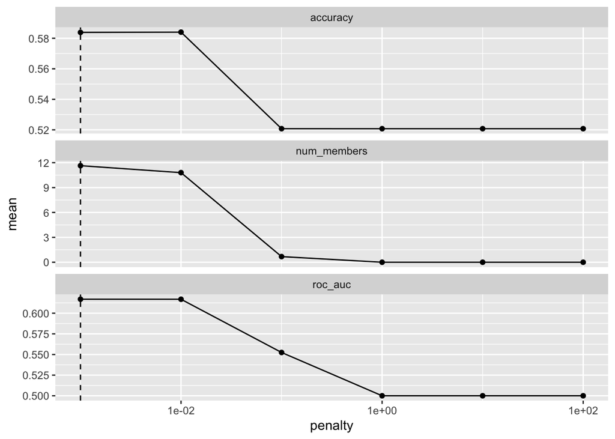

```r
autoplot(ensemble_model_st)
```

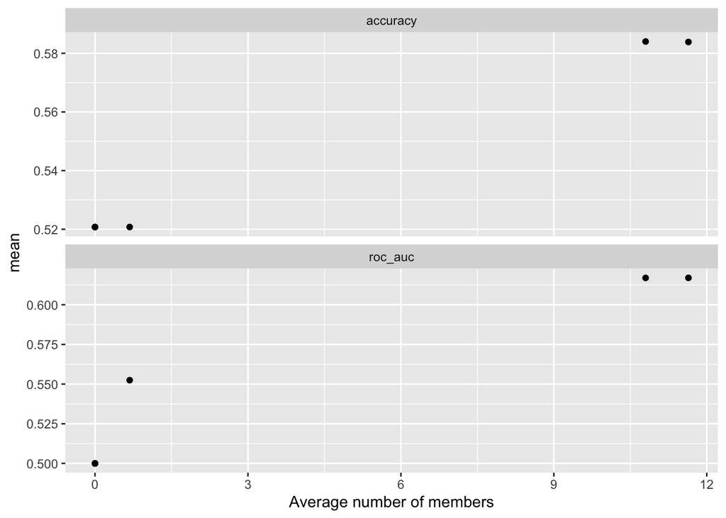

```r
autoplot(ensemble_model_st, type = "member")
```

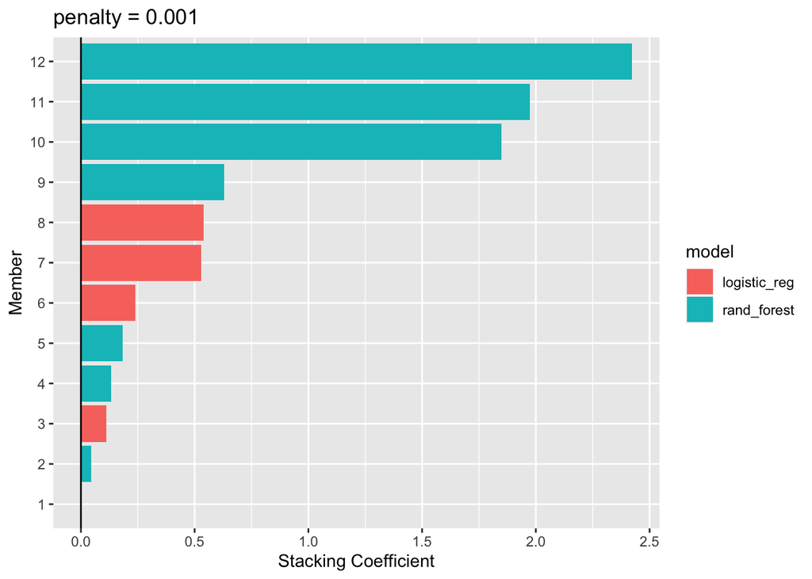

```r
autoplot(ensemble_model_st, type = "weights")
```

```r
collect_parameters(ensemble_model_st, "logit_res")
```

```
# A tibble: 131 × 5
   member           penalty mixture terms                       coef
   <chr>              <dbl>   <dbl> <chr>                      <dbl>
 1 logit_res_1_001 0.000001       0 .pred_long_logit_res_1_001     0
 2 logit_res_1_044 0.00811        0 .pred_long_logit_res_1_044     0
 3 logit_res_1_045 0.01           0 .pred_long_logit_res_1_045     0
 4 logit_res_1_046 0.0123         0 .pred_long_logit_res_1_046     0
 5 logit_res_1_047 0.0152         0 .pred_long_logit_res_1_047     0
 6 logit_res_1_048 0.0187         0 .pred_long_logit_res_1_048     0
 7 logit_res_1_049 0.0231         0 .pred_long_logit_res_1_049     0
 8 logit_res_1_050 0.0285         0 .pred_long_logit_res_1_050     0
 9 logit_res_1_051 0.0351         0 .pred_long_logit_res_1_051     0
10 logit_res_1_052 0.0433         0 .pred_long_logit_res_1_052     0
# ℹ 121 more rows
```

```r
collect_parameters(ensemble_model_st, "rf_res")
```

```
# A tibble: 15 × 5
   member       mtry trees terms                      coef
   <chr>       <int> <int> <chr>                     <dbl>
 1 rf_res_1_01     1   100 .pred_long_rf_res_1_01 2.42
 2 rf_res_1_02     1   200 .pred_long_rf_res_1_02 1.85
 3 rf_res_1_03     1   300 .pred_long_rf_res_1_03 1.97
 4 rf_res_1_04     2   100 .pred_long_rf_res_1_04 0
 5 rf_res_1_05     2   200 .pred_long_rf_res_1_05 0.000229
 6 rf_res_1_06     2   300 .pred_long_rf_res_1_06 0
 7 rf_res_1_07     3   100 .pred_long_rf_res_1_07 0
 8 rf_res_1_08     3   200 .pred_long_rf_res_1_08 0
 9 rf_res_1_09     3   300 .pred_long_rf_res_1_09 0
10 rf_res_1_10     4   100 .pred_long_rf_res_1_10 0.629
11 rf_res_1_11     4   200 .pred_long_rf_res_1_11 0.133
12 rf_res_1_12     4   300 .pred_long_rf_res_1_12 0.184
13 rf_res_1_13     5   100 .pred_long_rf_res_1_13 0.0459
14 rf_res_1_14     5   200 .pred_long_rf_res_1_14 0
15 rf_res_1_15     5   300 .pred_long_rf_res_1_15 0
```

```r
# FINAL CLASSIFICATION
mimic_pred <- test %>%
  bind_cols(predict(ensemble_model_st, ., type = "prob")) %>%
  print(width = Inf)
```

```
# A tibble: 32,043 × 38
   subject_id  hadm_id  stay_id gender age_at_intime los_long Bicarbonate
        <int>    <int>    <int> <fct>          <int> <fct>          <dbl>
 1   10000032 29079034 39553978 F                 52 short             25
 2   10000980 26913865 39765666 F                 76 short             21
 3   10001217 24597018 34592300 F                 55 short             22
 4   10001217 27703517 34592300 F                 55 short             22
 5   10002155 20345487 31090461 F                 83 short             23
 6   10002155 28994087 31090461 F                 82 long              23
 7   10002348 22725460 32610785 F                 77 long              22
 8   10002428 20321825 33987268 F                 81 long              25
 9   10002428 23473524 33987268 F                 81 long              25
10   10002428 28662225 33987268 F                 81 long              25
   Potassium Chloride Glucose Creatinine Hematocrit Sodium White_Blood_Cells
       <dbl>    <dbl>   <dbl>      <dbl>      <dbl>  <dbl>             <dbl>
```

[output cut: 71 more lines]

```r
ensemble_roc <- yardstick::roc_auc(
  mimic_pred,
  truth = los_long,
  contains(".pred_short")
)
```

```r
mimic_pred_results <-
  test |>
  select(los_long) |>
  bind_cols(
    predict(
      ensemble_model_st,
      test,
      type = "class",
      members = TRUE
    )
  ) |>
  print(width = Inf)
```

```
# A tibble: 32,043 × 14
   los_long .pred_class .pred_class_logit_res_1_101 .pred_class_logit_res_1_201
   <fct>    <fct>       <fct>                       <fct>
 1 short    short       short                       short
 2 short    short       short                       short
 3 short    short       short                       short
 4 short    short       short                       short
 5 short    long        short                       short
 6 long     short       short                       short
 7 long     short       short                       short
 8 long     long        long                        long
 9 long     long        long                        long
10 long     long        long                        long
   .pred_class_logit_res_1_301 .pred_class_logit_res_1_401
   <fct>                       <fct>
```

[output cut: 47 more lines]

```r
map(
  colnames(mimic_pred_results),
  ~ mean(mimic_pred_results$los_long == pull(mimic_pred_results, .x))
) |>
  set_names(colnames(mimic_pred_results)) |>
  as_tibble() |>
  pivot_longer(c(everything(), -los_long))
```

```
# A tibble: 13 × 3
   los_long name                        value
      <dbl> <chr>                       <dbl>
 1        1 .pred_class                 0.590
 2        1 .pred_class_logit_res_1_101 0.572
 3        1 .pred_class_logit_res_1_201 0.572
 4        1 .pred_class_logit_res_1_301 0.572
 5        1 .pred_class_logit_res_1_401 0.572
 6        1 .pred_class_rf_res_1_01     0.579
 7        1 .pred_class_rf_res_1_02     0.581
 8        1 .pred_class_rf_res_1_03     0.582
 9        1 .pred_class_rf_res_1_05     0.583
10        1 .pred_class_rf_res_1_10     0.581
11        1 .pred_class_rf_res_1_11     0.584
12        1 .pred_class_rf_res_1_12     0.585
13        1 .pred_class_rf_res_1_13     0.578
```

### 4. Comparing Model Performance

Note: I loaded these models from the RDS files to avoid running the code again. If you would like to reproduce these results, you may also uncomment the code in the code chunk below titled “load fitted models”, which has the same variable names as the models that were run above. Please uncomment and set `eval == TRUE` to run.

```r
# Load best logistic regression model RDS
logit_model <- readRDS("final_logit_fit_accuracy.rds")

# Load best random forest model RDS
rf_model <- readRDS("final_rf_fit_accuracy.rds")

# Load best gradient boosting model RDS
gb_model <- readRDS("final_gb_fit_accuracy.rds")

# Load best Multi-Layer Perceptron (MLP) model RDS
mlp_model <- readRDS("final_mlp_fit_accuracy.rds")
```

#### Importance Plots

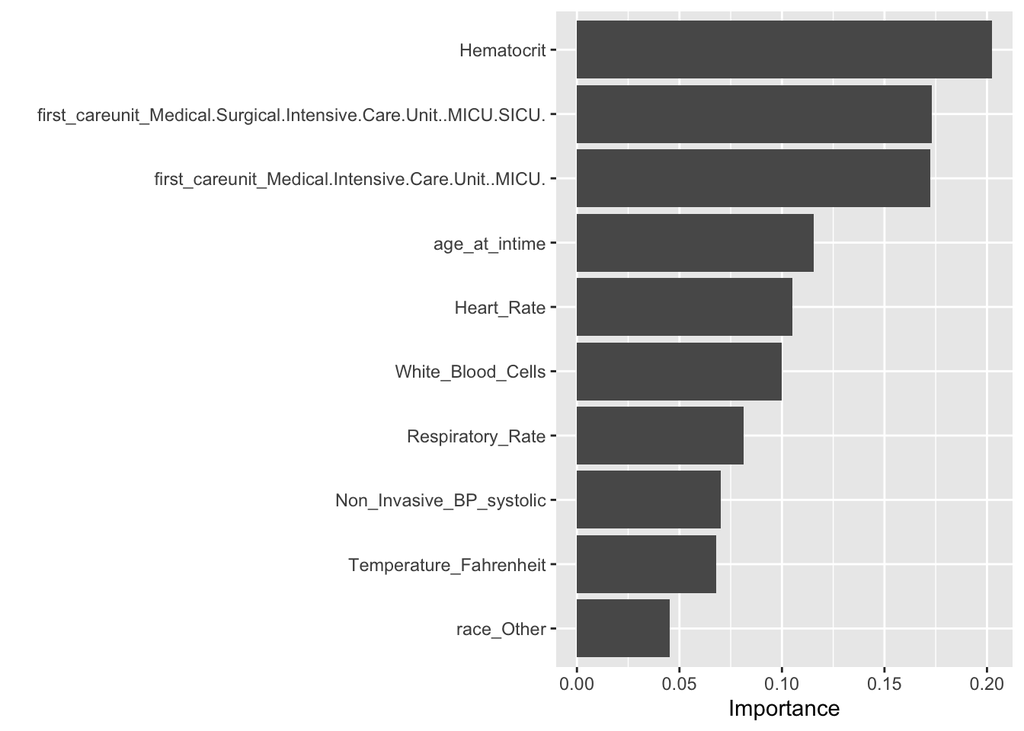

```r
# Importance Plots

# Logistic Regression
logit_model %>%
  extract_fit_parsnip() %>%
  vip()
```

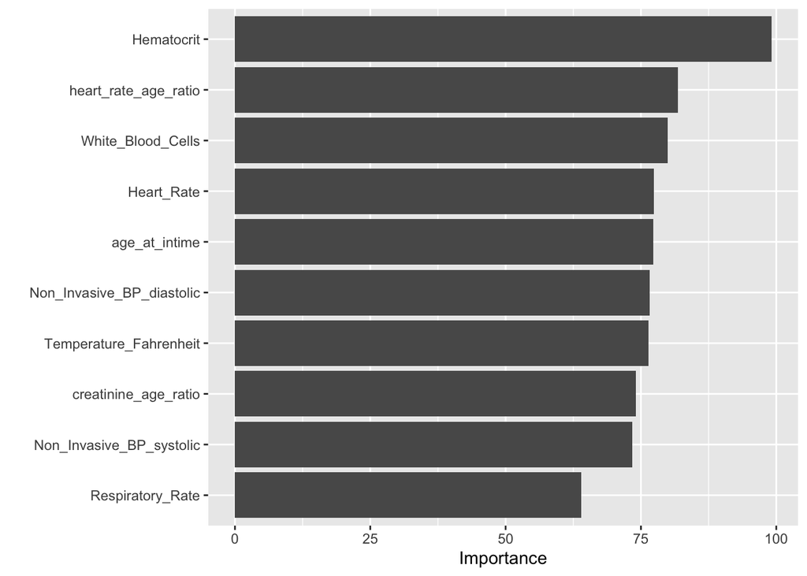

```r
# random forest
rf_model %>%
  extract_fit_parsnip() %>%
  vip()
```

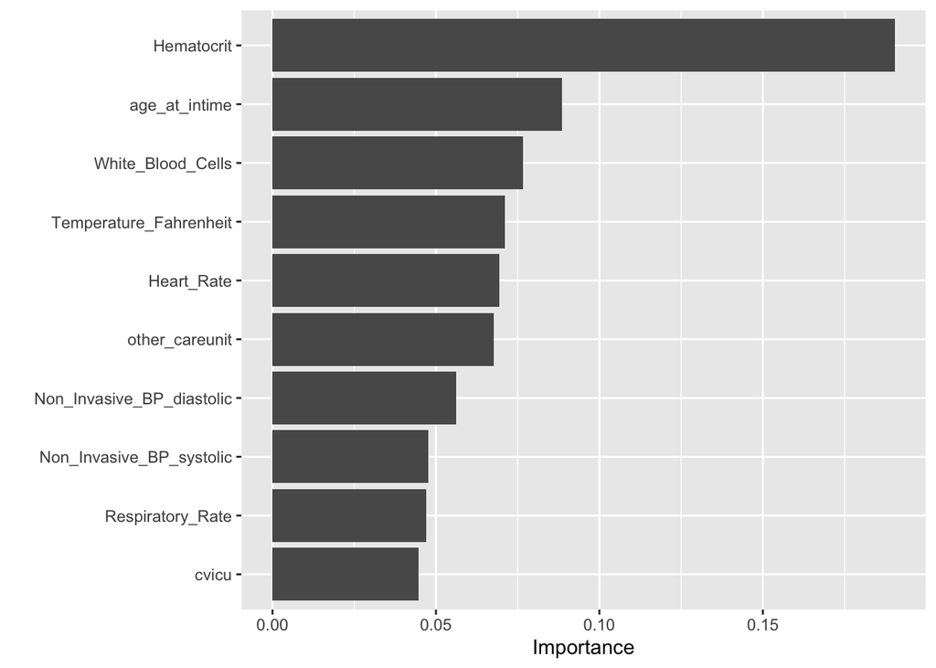

```r
# gradient boosting
gb_model %>%
  extract_fit_parsnip() %>%
  vip()
```

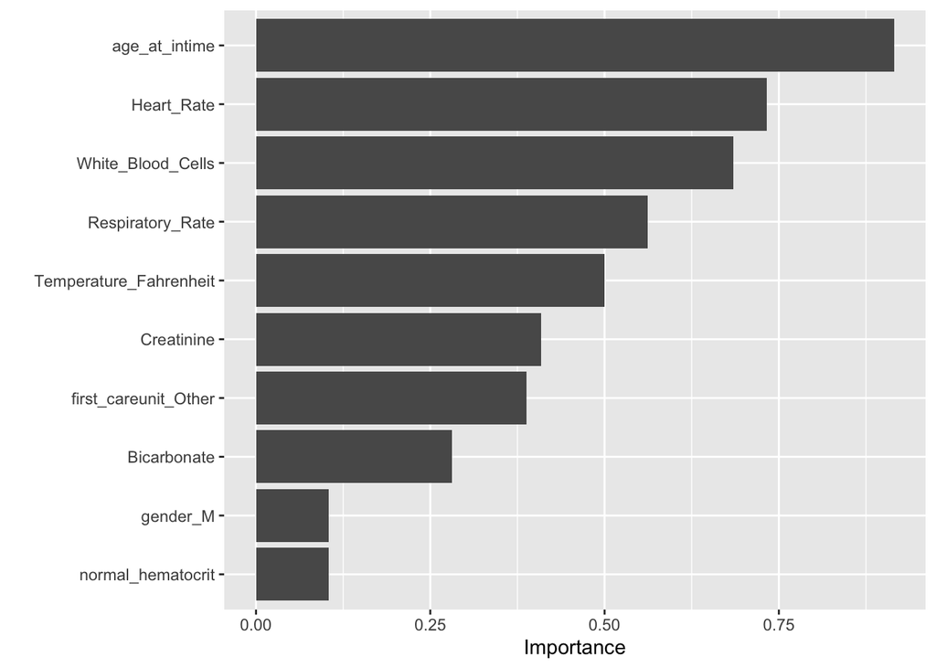

```r
# Multi-Layer Perceptron (MLP)
mlp_model %>%
  extract_fit_parsnip() %>%
  vip()
```

Please uncomment code chunk below for reproducible results.

```r
# load fitted models

# Please uncomment and set eval = TRUE to run.
#
# #Logistic Regression
# final_logit_fit %>%
#   extract_fit_parsnip() %>%
#   vip()
# logit_model<-final_logit_fit

# #random forest
# final_fit_rf %>%
#   extract_fit_parsnip() %>%
#   vip()
# rf_model<-final_fit_rf
#
# #gradient boosting
# final_fit_gb %>%
#   extract_fit_parsnip() %>%
#   vip()
# gb_model<-final_fit_gb
#
# #Multi-Layer Perceptron (MLP)
# final_fit_mlp %>%
#   extract_fit_parsnip() %>%
#   vip()
# mlp_model<-final_fit_mlp
```

#### Model Performance Comparison

```r
# Compare model classification performance on the test set
logit_model |> collect_metrics()
```

```
# A tibble: 2 × 4
  .metric  .estimator .estimate .config
  <chr>    <chr>          <dbl> <chr>
1 accuracy binary         0.574 Preprocessor1_Model1
2 roc_auc  binary         0.603 Preprocessor1_Model1
```

```r
rf_model |> collect_metrics()
```

```
# A tibble: 2 × 4
  .metric  .estimator .estimate .config
  <chr>    <chr>          <dbl> <chr>
1 accuracy binary         0.581 Preprocessor1_Model1
2 roc_auc  binary         0.621 Preprocessor1_Model1
```

```r
gb_model |> collect_metrics()
```

```
# A tibble: 2 × 4
  .metric  .estimator .estimate .config
  <chr>    <chr>          <dbl> <chr>
1 accuracy binary         0.585 Preprocessor1_Model1
2 roc_auc  binary         0.619 Preprocessor1_Model1
```

```r
mlp_model |> collect_metrics()
```

```
# A tibble: 2 × 4
  .metric  .estimator .estimate .config
  <chr>    <chr>          <dbl> <chr>
1 accuracy binary         0.571 Preprocessor1_Model1
2 roc_auc  binary         0.599 Preprocessor1_Model1
```

```r
ensemble_roc
```

```
# A tibble: 1 × 3
  .metric .estimator .estimate
  <chr>   <chr>          <dbl>
1 roc_auc binary         0.627
```

Compare model classification performance on the test set. Report both the area under ROC curve and accuracy for each machine learning algorithm and the model stacking. Interpret the results. What are the most important features in predicting long ICU stays? How do the models compare in terms of performance and interpretability?

**Summary of Model Performance:**

The results of the model performance are summarized below.

[output not shown]

**Model Comparison: Performance**

I used area under the Receiver Operating Characteristic (AUROC) and accuracy metrics to evaluate the classification performance of several models: Logistic Regression with elastic net, Random Forest, Gradient Boosting, Multi-Layer Perceptron (MLP), and Ensemble Model Stack with Logistic Regression Enet and Random Forest.

Overall, the ensemble model outperformed all other models with an AUROC of 0.6268539. This reflects the power of combining multiple models to improve predictive performance.

**Important Features and Interpretation of Results:**

To interpret the results, I used the Variable Importance Plot (VIP) to identify the most important features in predicting long ICU stays. The VIP plots depict the relative importance of each feature for each model.

All of the models except MLP captured `Hematocrit` as the most important feature in predicting long ICU stays. MLP failed to even identify `Hematocrit` as an important feature. This could be due to the complexity of the model with the structure of the neural network or the tuning parameters used. Perhaps the number of epochs or hidden units was not sufficient to capture the importance of `Hematocrit` as I had to greatly reduce it to expedite the tuning time.

However, MLP was able to identify many of the same top features other models recognized as important predictors of long ICU stays, such as `age_at_intime`, `White_Blood_Cells`, `Heart_Rate`, and `Temperature_Fahrenheit`. We can infer that age is a crucial predictor of long ICU stays because older patients are more likely to have longer ICU stays. Similarly, abnormal values of white blood cells, heart rate, and temperature are indicative of underlying health issues that may require longer ICU stays.

Interestingly, the first care unit played an pivotal role in only the logistic regression with enet regularization, which suggests that the type of care unit may influence the length of stay in the ICU. This makes sense as different care units have varying levels of care depending on the severity of the patient’s condition, which could impact the length of stay.

Some of the features I created in the feature engineering step emerged as top predictors as well. For example, `heart_rate_age_ratio` and `creatine_age_ratio` appeared in the top features in the VIP plot for Random Forest. This suggests that the ratios of heart rate and creatine to age are important predictors of long ICU stays, and creating these features helped improve the model’s performance. This algins with what I observed, as most of the models’ accuracy and AUROC increased after I implemented this feature engineering step.

**Model Comparison: Interpretability:**

In terms of interpretability, the Logistic Regression model with elastic net regularization is the most interpretable model. It provides coefficients for each feature, which allows us to understand the direction and strength of the relationship between the features and the outcome variable, `los_long`. In this case, we know that the first care unit and `Hematocrit` have the most influence in determining whether the patient will have a long ICU stay.

On the other hand, Random Forest and Gradient Boosting models are less interpretable because they are based on ensembles of decision trees, which are more complex and difficult to interpret. While they offer high predictive power and can capture complex relationships between features, the tradeoff is that they are less interpretable.

Compared to the other models, Random Forest shows that the importance levels across the features are not that different, which makes it harder to pinpoint the most important features. For example, Hematocrit is the most important feature in Random Forest, but its importance level is only marginally higher than the next 9 important features.

In contrast, Gradient Boosting shows a stark contrast between Hematocrit and the second most important feature, which is `age_at_intime`. However, the rest of the features are close to each other in importance level so it becomes unclear which other features significantly impact the predictions.